# ECL749 Ateliers R

François Rousseu

Hiver 2021

# Atelier 1

## R et RStudio

[R](https://cran.r-project.org/) est un langage et un environnement pour le calcul scientifique et les graphiques. Il peut cependant être utilisé pour bien d’autres choses puisqu’il s’agit avant tout d’un langage de programmation.

[RStudio](https://www.rstudio.com/) est en quelque sorte un éditeur de texte avancé facilitant l’utilisation et la communication avec R. À l’intérieur de cette interface, vous pouvez créer un script avec vos lignes de commande qui pourront être envoyées dans la console R. Il y a beaucoup de fonctionnalités dans RStudio et ces dernières sont décrites dans cette *cheat sheet*: [RStudio IDE Cheat Sheet](https://www.rstudio.com/resources/cheatsheets/#ide)

## Opérations et objets de base

R peut être utilisé comme une simple calculatrice!

```r
3 * 4
```

```
## [1] 12
```

```r
13/3
```

```
## [1] 4.333333
```

```r
3^3
```

```
## [1] 27
```

On peut également assigner des objets à des symboles avec l’opérateur `<-` et concaténer des nombres ensemble avec la fonction `c` pour créer un vecteur, un objet à **1 dimension**. Par la suite, on peut effectuer des opérations vectorisées, i.e. à chaque élément du vecteur.

```r
v1 <- c(1, 2, 3, 4, 5, 6, 7, 8, 9)
v1
```

```
## [1] 1 2 3 4 5 6 7 8 9
```

```r
v2 <- c(10, 10, 10, 10, 10, 10, 10, 10, 10)
v1 + v2
```

```
## [1] 11 12 13 14 15 16 17 18 19
```

```r
v1 * v2 + 1
```

```
## [1] 11 21 31 41 51 61 71 81 91
```

On peut aussi coller ces deux vecteurs ensembles pour créer une matrice (`matrix`), un objet à **2 dimension**.

```r
m <- cbind(v1, v2)  #! Colle deux vecteurs ensemble
m
```

```
##       v1 v2
##  [1,]  1 10
##  [2,]  2 10
##  [3,]  3 10
##  [4,]  4 10
##  [5,]  5 10
##  [6,]  6 10
##  [7,]  7 10
##  [8,]  8 10
##  [9,]  9 10
```

Une matrice est composée d’un même type de valeurs, soit numérique, caractère ou logique. Plus général, un `data.frame` peut contenir plusieurs types de valeurs. C’est l’équivalent d’un tableau de données dans Excel.

```r
d <- data.frame(v1, v2, z = c("a", "b", "c", "d", "e", "f", "g", "h", "i"))
d
```

```
##   v1 v2 z
## 1  1 10 a
## 2  2 10 b
## 3  3 10 c
## 4  4 10 d
## 5  5 10 e
## 6  6 10 f
## 7  7 10 g
## 8  8 10 h
## 9  9 10 i
```

Les listes peuvent contenir tout type d’objets et sont des objets à une dimension.

```r
l <- list(v1, m, d)
l
```

```
## [[1]]
## [1] 1 2 3 4 5 6 7 8 9
##
## [[2]]
##       v1 v2
##  [1,]  1 10
##  [2,]  2 10
##  [3,]  3 10
##  [4,]  4 10
##  [5,]  5 10
##  [6,]  6 10
##  [7,]  7 10
##  [8,]  8 10
##  [9,]  9 10
##
## [[3]]
##   v1 v2 z
## 1  1 10 a
## 2  2 10 b
## 3  3 10 c
## 4  4 10 d
## 5  5 10 e
## 6  6 10 f
## 7  7 10 g
## 8  8 10 h
## 9  9 10 i
```

### Type de données

Les principaux types de données ou de valeurs dans R sont:

```r
x <- c(1, 2, 3, 4, 5)
class(x)
```

```
## [1] "numeric"
```

```r
x <- c("bonjour", "allo", "bye")
class(x)
```

```
## [1] "character"
```

```r
x <- c(TRUE, TRUE, FALSE)
class(x)
```

```
## [1] "logical"
```

Il y a également le type de données correspondant à un facteur (**factor**),

```r
x <- c("bonjour", "allo", "bye", "allo", "bye")
x <- factor(x)
class(x)
```

```
## [1] "factor"
```

Si on affiche cet objet dans la console:

```r
x
```

```
## [1] bonjour allo    bye     allo    bye
## Levels: allo bonjour bye
```

Les *factors* sont des vecteurs de catégories ayant chacune une étiquette et représentées de façon interne par des entiers. Par défaut, les étiquettes sont numérotées par ordre alphabétique.

### Objets de données

- `vector` (1 dimension, 1 type de données)
- `matrix` (2 dimensions, 1 type de données)
- `data.frame` (2 dimensions, tout type de données)
- `list` (1 dimension, tout type d’objets)
- `array` (3 dimension, un type de données)

### Objets et assignation

Tout ce qui est contenu dans une session R est un **objet** qui porte un nom. Lorsque l’on modifie un objet, il faut se rappeler d’assigner le résultat afin de le conserver dans le même objet ou dans un nouvel objet. Par exemple, affichons le contenu de v1:

```r
v1
```

```
## [1] 1 2 3 4 5 6 7 8 9
```

Maintenant, ajoutons une valeur à v1:

```r
v1 + 100
```

```
## [1] 101 102 103 104 105 106 107 108 109
```

Le résultat s’affiche, mais l’objet n’a toujours pas changé:

```r
v1
```

```
## [1] 1 2 3 4 5 6 7 8 9
```

L’objet `v1` n’a toujours pas changé, car il faut assigner le résultat à un nouvel objet ou à l’objet v1 en “écrasant” l’ancien objet v1.

```r
v1 <- v1 + 100
v1
```

```
## [1] 101 102 103 104 105 106 107 108 109
```

Tout ce qui est contenu dans une session R est un **objet** qui porte un nom.

## Accéder aux données

L’accès aux données se fait par l’intermédiaire de l’indexation qui est le processus par lequel on accède aux données à l’intérieur d’un objet. Pour ce faire, on utilise généralement les opérateurs `[` et `$` avec différentes conditions pour établir notre sélection.

### Avec un vecteur

```r
v1
```

```
## [1] 101 102 103 104 105 106 107 108 109
```

On accède au 3e élément du vecteur.

```r
v1[3]
```

```
## [1] 103
```

On accède à tous les éléments supérieurs à 105.

```r
v1[v1 > 105]
```

```
## [1] 106 107 108 109
```

On accède à tous les éléments supérieurs à 105 et inférieurs ou égal à 108.

```r
v1[v1 > 105 & v1 <= 108]
```

```
## [1] 106 107 108
```

### Avec un `data.frame`

Un `data.frame` est un objet en 2 dimensions qui contient des lignes et des colonnes `d[i, j]`.

```r
d
```

```
##   v1 v2 z
## 1  1 10 a
## 2  2 10 b
## 3  3 10 c
## 4  4 10 d
## 5  5 10 e
## 6  6 10 f
## 7  7 10 g
## 8  8 10 h
## 9  9 10 i
```

On sélectionne les lignes 4 à 6 du `data.frame`.

```r
d[4:6, ]
```

```
##   v1 v2 z
## 4  4 10 d
## 5  5 10 e
## 6  6 10 f
```

On sélectionne les colonnes 1 et 3 du `data.frame`.

```r
d[, c(1, 3)]
```

```
##   v1 z
## 1  1 a
## 2  2 b
## 3  3 c
## 4  4 d
## 5  5 e
## 6  6 f
## 7  7 g
## 8  8 h
## 9  9 i
```

On sélectionne la colonne nommée `z`.

```r
d$z
```

```
## [1] "a" "b" "c" "d" "e" "f" "g" "h" "i"
```

On sélectionne toutes les lignes où `v1` est supérieur à 7.

```r
d[d$v1 > 7, ]
```

```
##   v1 v2 z
## 8  8 10 h
## 9  9 10 i
```

### Avec une liste

Avec les “`[`” simples, on accède aux éléments de la liste qui sont aussi retournés sous forme de liste.

```r
l[1]
```

```
## [[1]]
## [1] 1 2 3 4 5 6 7 8 9
```

Avec les doubles “`[[`”, on accède directement à un seul élément contenu dans la liste.

```r
l[[1]]
```

```
## [1] 1 2 3 4 5 6 7 8 9
```

On peut également accéder aux éléments de la liste par leur nom si cette liste est nommée.

```r
l$v1
```

[output not shown]

Puisque la liste n’est pas nommée, la valeur `NULL` nous est retournée.

```r
names(l) <- c("allo", "bonjour", "bye")
l$bye
```

```
##   v1 v2 z
## 1  1 10 a
## 2  2 10 b
## 3  3 10 c
## 4  4 10 d
## 5  5 10 e
## 6  6 10 f
## 7  7 10 g
## 8  8 10 h
## 9  9 10 i
```

## Fonctions

On retrouve également dans R des objets qui sont des **fonctions**. Les fonctions peuvent être appliquées à des objets pour obtenir des résultats. On applique les fonctions aux objets en utilisant les parenthèses `()`, contrairement aux crochets `[]` qui servent à l’indexation. Par exemple, `c` est une fonction qui permet de coller des valeurs ensembles dans un vecteur.

```r
temp <- c(37, 54, 79, 23, 3, 101, 4)
```

La fonction `mean` permet de calculer des moyennes et la fonction `sd` des écarts-types.

```r
mean(temp)
sd(temp)
```

```
## [1] 43
## [1] 37.27823
```

```r
rep(1:3, times = 5)
```

```
##  [1] 1 2 3 1 2 3 1 2 3 1 2 3 1 2 3
```

### Arguments

Ceci permet d’introduire les *arguments* qui composent les fonctions. On pourrait aussi utiliser l’argument `length.out` ou `each` pour modfifier la façon dont les valeurs sont répétées.

```r
rep(1:3, each = 5)
rep(1:3, length.out = 5)
```

```
##  [1] 1 1 1 1 1 2 2 2 2 2 3 3 3 3 3
## [1] 1 2 3 1 2
```

En général, la majorité des arguments d’une fonction ont des valeurs par défaut. Par exemple, les valeurs par défaut de `rep` sont `times = 1`.

```r
rep(1:3)
```

```
## [1] 1 2 3
```

Par défaut, le premier élément listé à l’intérieur d’une fonction est l’objet auquel on veut l’appliquer et correspond au premier argument de la fonction. Cet argument n’a généralement par besoin d’être nommé. Par contre, il est souvent préférable ou nécessaire de nommer les éléments suivants. Si ceux-ci ne sont pas nommés, l’ordre dans lequel ils sont donnés sera utilisé pour les associer aux arguments correspondant.

### Opérateurs

Certaines fonctions sont représentées par des opérateurs. En voici quelques exemples.

```r
3 == 4  # égal
```

```
## [1] FALSE
```

```r
3 + 4  # addition
```

```
## [1] 7
```

```r
TRUE & TRUE  # 'et' logique
```

```
## [1] TRUE
```

```r
TRUE & FALSE  # 'et' logique
```

```
## [1] FALSE
```

```r
3 == 4 | 3 == 5  # 'ou' logique
```

```
## [1] FALSE
```

```r
c(3, 4) %in% c(4, 5, 6, 7)  # élément du vecteur 1 contenule vecteur 2
```

```
## [1] FALSE  TRUE
```

```r
3:10  # crée un vecteur avec tous les entiers de 3 à 10
```

```
## [1]  3  4  5  6  7  8  9 10
```

## Importation des données

### Le répertoire courant

Lorsqu’on débute avec R, c’est souvent à cette première étape cruciale qu’on a des problèmes! Premièrement, R travaille dans un seul dossier à la fois, c’est-à-dire que la base de données doit être dans le bon dossier, appelé **répertoire courant** (*Working Directory*). Pour dire à R quel est ce dossier, on va dans RStudio sous l’onglet *Session > Set Working Directory*. On doit généralement faire cette opération à chaque début de session de travail dans R, à moins que RStudio s’ouvre par défaut au bon endroit. On peut également inspecter le répertoire courant à l’aide de la fonction `getwd`.

```r
getwd()
```

```
## [1] "C:/Users/User/Documents/GitHub/ECL749"
```

Pour s’assurer que notre base de données se trouve bien à cet endroit, on peut utiliser la fonction `list.files`.

```r
list.files()
```

```
## [1] "data"           "ECL749.Rproj"   "index.html"     "index.Rmd"
## [5] "lab"            "plage_type.csv" "README.md"
```

### Les données manquantes (NA)

Avant d’importer des données, il est nécessaire d’aborder la gestion des données manquantes par R. Les données manquantes sont toujours représentées par des `NA`, que ce soit dans les vecteurs ou dans les tableaux de données. Lorsqu’on veut importer des données avec des cellules vides, il est souvent nécessaire de remplacer les cellules vides par des `NA`. Parfois, il est possible de dire à une éventuelle fonction que les cellules vides correspondent à des `NA`.

### Les fonctions d’importation

Il existe plusieurs méthodes pour importer des données dans R. La façon classique est par l’intermédiaire de la fonction `read.table`. Cette fonction prend des fichiers textes (*.txt*) qui doivent répondre à plusieurs critères:

- Il ne doit y avoir aucun espace dans les noms des différentes variables et dans les éléments de la base de données. Par exemple, «bon à modéré» va créer des problèmes. On devrait plutôt écrire “bon.à.modéré” ou “bon_à_modéré”. Encore mieux serait d’éviter les accents ou d’utiliser un code.
- **AUCUNE** cellule ne doit être vide. Si une cellule est vide ou si on a écrit un commentaire au lieu d’un nombre, on écrit `NA` dans la cellule. Autrement, R produira un message d’erreur puisqu’il considérera qu’une ligne du tableau est incomplète.
- Il faut généralement utiliser le point plutôt que la virgule pour les nombres décimaux (à moins de le spécifier dans les arguments). Autrement, une virgule sera considérée comme étant du caractère.
- Par défaut, les colonnes contenant du texte ou tout caractère ne pouvant pas être interprétés comme un chiffre seront considérées comme étant des colonnes contenant du texte (*character*) et seront automatiquement converties en *factor* par les fonctions d’importation de base comme `read.table`. Pour éviter ceci, il est possible de spécifier l’argument `stringsAsFactors = FALSE`.

Les messages d’erreurs sont très très fréquents lors de l’importation d’une nouvelle base de données. Il s’agit d’être en mesure de bien les interpréter et d’observer ces quelques règles de base.

Plusieurs autres fonctions sont disponibles selon le format des données (`read.delim`, `read.csv`, etc.). Le format *.csv* est souvent le plus pratique, car il réduit les risques de problèmes lors de l’importation en raison de la délimitation des cellules. Il est également possible d’utiliser le package **readxl** pour lire directement des fichiers `.xlsx`. Bien qu’étant la façon classique d’importer des données, la fonction `read.table` est assez capricieuse… On peut également exporter des données avec les fonctions `write.table` ou `write.csv`.

Voici les fonctions de base les plus souvent utilisées pour importer des données:

- `read.table` : pour des fichiers *.txt*
- `read.csv` : pour des fichiers *.csv* (c’est la meilleure façon)
- `read_excel` : fonction du package **readxl** pour des fichiers *.xlsx*

Voici un exemple:

```r
getwd()
d <- read.table("data.txt", header = TRUE)
```

```
## Error in file(file, "rt"): cannot open the connection
```

[output not shown]

Le code précédent se base sur le fait que le fichier de données est dans le répertoire courant. Si ce n’était pas le cas, il serait aussi possible de spécifier l’emplacement exact du fichier à charger en indiquant le chemin au complet. De cette façon, il est possible d’aller chercher des bases de données ailleurs que dans le répertoire courant.

```r
d <- read.table("C:/Users/rouf1703/Documents/UdeS/GitHub/ECL749/lab/data.txt", header = TRUE)
```

```
## Error in file(file, "rt"): cannot open the connection
```

### Inspection des données

Il existe plusieurs fonctions pour inspecter les données suite à leur importation ou pour inspecter un `data.frame`. Lors de l’importation de données, il est fortement recommandé de faire un peu d’inspection pour s’assurer que le tout est conforme à nos attentes.

La fonction `dim` permet de connaître le nombre de lignes (*i*) et le nombres de colonnes (*j*) d’un `data.frame`.

```r
dim(d)
```

```
## [1] 9 3
```

La fonction `head` permet d’observer les 6 premières lignes.

```r
head(d)
```

```
##   v1 v2 z
## 1  1 10 a
## 2  2 10 b
## 3  3 10 c
## 4  4 10 d
## 5  5 10 e
## 6  6 10 f
```

La fonction `str` permet d’inspecter le type de données dans chacune des colonnes.

```r
str(d)
```

```
## 'data.frame':    9 obs. of  3 variables:
##  $ v1: num  1 2 3 4 5 6 7 8 9
##  $ v2: num  10 10 10 10 10 10 10 10 10
##  $ z : chr  "a" "b" "c" "d" ...
```

La fonction `summary` permet de résumer les données dans chacune des colonnes.

```r
summary(d)
```

```
##        v1          v2          z
##  Min.   :1   Min.   :10   Length:9
##  1st Qu.:3   1st Qu.:10   Class :character
##  Median :5   Median :10   Mode  :character
##  Mean   :5   Mean   :10
##  3rd Qu.:7   3rd Qu.:10
##  Max.   :9   Max.   :10
```

## Exercice

Ce premier exercice consiste à importer une base de données en format *.txt*. Cette base de données contient des mesures morphométriques d’une espèce de bruant (un oiseau). Vous pouvez la télécharger à l’adresse suivante:

https://raw.githubusercontent.com/frousseu/ECL749/master/data/sparrows.txt

Vous devez utiliser le bouton droit de la souris pour sauvegarder le contenu de la page dans un fichier *.txt*.

Par la suite, vous devez calculer la longueur moyenne de la corde de l’aile (**wingcrd**) et de la masse (**wt**) et effectuez un graphique mettant en relation les deux mesures. La fonction `plot` devrait vous être utile.

Vous devez également utiliser la fonction `table` pour compter le nb d’observations de mâles et de femelles et apprendre le fonctionnement de la fonction `boxplot` pour comparer la variabilité de la masse chez les deux sexes.

Finalement, effectuez et interprétez un test de t pour comparer la masse chez les deux sexes. Ici, la fonction `subset` pourrait être utile, mais il est possible de s’en sortir en utilisant seulement l’indexage (les `[ ]`).

Il y a peut-être quelques petits problèmes avec la base de données…

### Solution

On télécharge le fichier *sparrows.txt* avec le bouton de droit en appuyant sur le bouton *raw*. On met ce fichier à un endroit correspondant au répertoire courant ou on change le répertoire courant pour celui de l’emplacementr du fichier. Vous pouvez aussi utiliser le menu de RStudio *Session > Set Working Directory > Choose Directory*. Remarquez que la ligne `setwd("chemin/vers/le/fichier.txt")` va s’écrire dans la console. Le mieux serait d’inclure cette ligne dans votre script. Remarquez qu’il serait aussi possible d’écrire le chemin vers le fichier au long au lieu de seulement inscrire le nom du fichier (entre guillemets) pour la fonction `read.table`.

```r
setwd("C:/Users/rouf1703/Desktop")
```

```
## Error in setwd("C:/Users/rouf1703/Desktop"): cannot change working directory
```

```r
d <- read.table("sparrows.txt", header = TRUE)
```

```
## Error in file(file, "rt"): cannot open the connection
```

[output not shown]

```r
mean(d$wingcrd)
```

```
## [1] NA
```

```r
mean(d$wt)
```

```
## Warning in mean.default(d$wt): argument is not numeric or logical: returning NA
```

```
## [1] NA
```

```r
mean(d$wingcrd, na.rm = TRUE)
```

```
## Warning in mean.default(d$wingcrd, na.rm = TRUE): argument is not numeric or
## logical: returning NA
```

```
## [1] NA
```

```r
mean(d$wt, na.rm = TRUE)
```

```
## [1] NA
```

```r
d$wt
```

[output not shown]

```r
mean(d$wingcrd, na.rm = TRUE)
```

```
## [1] NA
```

```r
mean(d$wt, na.rm = TRUE)
```

```
## [1] NA
```

```r
plot(d$wingcrd, d$wt)
```

```
## Error in plot.window(...): need finite 'xlim' values
```

```r
table(d$Sex)
```

```
## < table of extent 0 >
```

La fonction `boxplot` nous permet de comparer la masse chez les deux sexes.

```r
boxplot(wt ~ Sex, data = d)
```

```
## Error in eval(predvars, data, env): object 'wt' not found
```

Remarquez la forme des arguments de la fonction `boxplot`. Ceux-ci sont donnés sous forme de formule (`?formula`) et non sous forme de caractères entre guillemets. Avec l’argument `data`, la fonction `boxplot` va chercher dans le `data.frame` les noms de colonnes correspondants. Cette façon de spécifier les variables sous forme de formule sera beaucoup utilisée lorsque nous ferons des modèles.

Par la suite, nous devons trouver le moyen de séparer les mâles des femelles afin d’effectuer notre test de t. Pour ce faire, il est possible d’utiliser la fonction `subset` ou simplement d’utiliser l’indexage. Les 4 lignes suivantes produisent les mêmes objets.

```r
m <- subset(d, subset = Sex == "m")
```

```
## Error in eval(e, x, parent.frame()): object 'Sex' not found
```

```r
f <- subset(d, subset = Sex == "f")
```

```
## Error in eval(e, x, parent.frame()): object 'Sex' not found
```

```r
m <- d[d$Sex == "m", ]
f <- d[d$Sex == "f", ]
```

Un peu comme dans la fonction `boxplot`, il n’est pas nécessaire d’utiliser les guillemets ou le `$` puisque la fonction `subset` cherchera dans le `data.frame` soumis pour trouver la colonne demandée (ici, *Sex*). Avec l’indexage régulier, il faut toutefois identifé où se trouve la colonne avec `d$Sex`. Par la suite, on effectue notre test de t.

```r
t.test(m$wt, f$wt)
```

```
## Error in var(x): 'x' is NULL
```

Plutôt que de séparer les mâles et les femelles en deux `data.frame`, il serait encore plus efficace d’utiliser une formule pour spécifier notre test de t.

```r
t.test(wt ~ Sex, data = d)
```

```
## Error in eval(predvars, data, env): object 'wt' not found
```

## Retour

### Script et console

Un script R est un fichier *.R* où on écrit le code qu’on veut conserver et à partir duquel on peut envoyer les différentes lignes de codes vers la console R. La console est l’endroit où sont évalué les différentes commandes et où les objets de la session R sont contenus. On peut écrire directement dans la console pour envoyer des commandes, mais il est préférable d’écrire ces commandes dans un script lorsqu’on veut conserver les commandes importantes.

### Insertion de commentaires

Pour insérer des commentaires dans un script, on utilise le dièse `#` (ou, pour utiliser un langage plus moderne, le *hashtag*…). Ces lignes ne seront pas interprétées lorsque’elle seront envoyées à la console.

```r
# Voici un commentaire qui ne sera pas interprété comme une commande
```

### Environnement de travail

Il est possible de sauvegarder à la fois un script (un fichier *.R*) qui contient du code ou un environnement de travail (un fichier *.RData*, le *Workspace*) qui contient les objets créés dans l’environnement. En général, il est beaucoup plus utile de conserver un script avec le code important puisque celui-ci peut être relancé à nouveau et c’est celui qui contient le travail important. Sauvegarder l’environnement de travail n’est généralement utile que si on crée des objets longs à produire ou si on veut partager des objets avec d’autres personnes par exemple. Pour sauvergarder l’environnement de travail, on peut aller sous le menu de RStudio et faire *Session > Save Workspace As*. Il est également possible de conserver l’historique des commandes, mais ceci n’est pas très utile puisque cela conserve l’ensemble des commandes qui ont été envoyées à la console, y compris les commandes contenant des erreurs.

### Importation de données

Comme vous avez pu le constater, l’importation de données avec `read.table` peut être ardue lorsque l’on débute. Pour éviter beaucoup de problème, une inspection préalable de la base de données est souvent nécessaire. Le message d’erreur le plus commun est probablement celui-ci.

```r
d <- read.table("Sparrows.txt", header = TRUE)
```

```
## Error in file(file, "rt"): cannot open the connection
```

Ce message indique que soit on a fait une erreur dans le nom du fichier, soit le fichier ne se trouve pas dans le répertoire courant. Dans cet exemple, il s’agit d’une erreur dans le nom du fichier. Remarquez également l’utilisation de l’argument `header` pour spécifier que la première ligne du tableau de données contient les noms de colonnes. Un autre argument très utilisé est `stringsAsFactors = FALSE` qui permet de spécfier que les données de type caractère ne doivent pas être automatiquement converties en `factor`.

#### Nom du fichier / chemin

Avec la plupart des fonctions d’importation, on peut soit donner le nom du fichier (avec l’extension) si celui-ci se trouve dans le répertoire courant, soit donner le chemin complet vers où le fichier se trouve.

```r
d <- read.table("C:/Users/rouf1703/Desktop/sparrows.txt", header = TRUE)
```

De cette façon, on s’affranchit du répertoire courant, car on indique directement à R où aller chercher le fichier. Ceci peut être très utile lorsqu’on ne veut pas changer le répertoire courant à chaque session ou si on a des fichiers classés à différents endroits sur l’ordinateur.

#### Autres fonctions d’importation

L’importation de fichiers *.txt* est la base, mais il est souvent plus facile d’utiliser le format *.csv* et la fonction `read.csv`. Ce format cause généralement moins de problèmes avec les cellules vides et la séparation entre les différentes colonnes est souvent moins ambigue qu’avec les espaces ou les tabulations.

Il est également possible de lire directement dans un fichier Excel avec les packages [readxl](https://cran.r-project.org/web/packages/readxl/index.html) et [xlsx](https://cran.r-project.org/web/packages/xlsx/index.html), mais je vais vous laisser le soin d’étudier ces possibilités.

### Inspection des données

Une fois qu’une base de données est importée, plusieurs fonctions peuvent être utilisées pour inspecter un `data.frame`. Les plus communes sont les fonctions `head`, `str`, `summary`. Voici des exemples.

```r
head(d)
```

```
##   v1 v2 z
## 1  1 10 a
## 2  2 10 b
## 3  3 10 c
## 4  4 10 d
## 5  5 10 e
## 6  6 10 f
```

```r
str(d)
```

```
## 'data.frame':    9 obs. of  3 variables:
##  $ v1: num  1 2 3 4 5 6 7 8 9
##  $ v2: num  10 10 10 10 10 10 10 10 10
##  $ z : chr  "a" "b" "c" "d" ...
```

```r
summary(d)
```

```
##        v1          v2          z
##  Min.   :1   Min.   :10   Length:9
##  1st Qu.:3   1st Qu.:10   Class :character
##  Median :5   Median :10   Mode  :character
##  Mean   :5   Mean   :10
##  3rd Qu.:7   3rd Qu.:10
##  Max.   :9   Max.   :10
```

La fonction `head` affiche les 6 premières lignes d’un `data.frame`. La fonction `str` liste les colonnes et informe sur le type de données dans chacune de celles-ci. La fonction `summary` calcule un résumé de l’information dans chaque colonne qui dépend du type de données.

Il est également possible d’inspecter les objets en utilisant l’onglet *Environment* dans RStudio et en cliquant sur les différents objets.

### Les guillemets

Les guillemets sont régulièrement utilisés dans R pour indiquer des valeurs correspondant à des caractères. Par exemple, le nom d’un fichier doit être donné entre guillemets à la fonction `read.table`. Pour certaines fonctions (e.g. `library`, `subset`) et pour les fonctions avec des formules et un argument `data`, les guillemets ne sont pas nécessaires. Il peut être frustrant au début de distinguer entre ces deux possibilités, mais on finit par s’y habituer. Encore une fois, se référer au fichier d’aide!

### `=` vs. `==`

Le signe d’égalité simple `=` est la plupart du temps utilisé pour spécifier un argument à une fonction. Il peut parfois être utilisé pour faire des assignations au lieu de la flèche d’assignation `<-`, mais on recommande d’éviter cette pratique. Le double `==` est utilisé comme une fonction pour tester l’égalité entre des valeurs ou des objets.

### Les facteurs

Étudions un peu plus les facteurs. Comme dit plus haut, un `factor` est un vecteur avec différents niveaux ayant une étiquette et représenté de façon interne par des entiers. Par défaut, les étiquettes sont classées par ordre alphabétique pour établir la représentation en entier. En général, avant de faire une analyse statistique comportant des facteurs, il faut s’assurer que nos variables catégoriques sont converties en tant que tel avec les fonctions `factor` ou `as.factor`. Ceci est particulièrement important pour les facteurs représentés par des valeurs numériques. Autrement, les modèles risquent de considérer ces variables comme numériques.

```r
v <- c("c", "b", "b", "a", "a", "a")
v <- factor(v)
v
```

```
## [1] c b b a a a
## Levels: a b c
```

```r
as.numeric(v)
```

```
## [1] 3 2 2 1 1 1
```

```r
as.character(v)
```

```
## [1] "c" "b" "b" "a" "a" "a"
```

```r
levels(v)
```

```
## [1] "a" "b" "c"
```

```r
mean(v)
```

```
## [1] NA
```

```r
v + 1
```

```
## [1] NA NA NA NA NA NA
```

# Atelier 2

## Consultez l’aide!

Avant d’utiliser une fonction, il faut se rappeler que c’est toujours un bon réflexe de consulter l’aide et particulièrement les exemples qui montrent souvent comment utiliser la fonction et ses arguments.

## Sauvegarde du travail

Suite à une session de travail dans R, il est généralement possible de sauvegarder deux types d’éléments soit un fichier de commande (ou un script R, *nomdufichier.R*) ou l’environnement de travail (un *workspace*, *nomdufichier.RData*).

Le premier sert à conserver les lignes de commandes et le second à conserver les objets générés dans la session de travail. En général, le plus important est de sauvegarder les lignes de commandes utilisées. Pour ce faire, il faut cliquer sur le bouton disquette en haut à gauche du panneau des scripts. Par la suite, il est possible d’envoyer à nouveau nos lignes de commande pour produire la tâche désirée.

## Script .R

- Fichier de commande ou script permettant de refaire les analyses. **C’est ce qui est important à conserver!**
- On peut ouvrir un script *.R* avec le menu de RStudio en faisant: *File > Open File* ou en utilisant le bouton d’ouverture de dossier.
- On peut insérer des commentaires dans un script avec le symbole `#` de cette façon:

```r
# permet de répéter 2 fois le vecteur allant de 1 à 5
rep(1:5, 2)
```

```
##  [1] 1 2 3 4 5 1 2 3 4 5
```

## .RData

- Environnement de travail avec les objets de la console R au moment de la sauvegarde (mais ne contient pas les lignes de commandes!)
- On peut le conserver au besoin en utilisant la fonction `save` ou en suivant dans le menu de RStudio *Session > Save Workspace As*
- On peut ouvrir un environnement de travail avec la fonction `load` ou en faisant *Session > Load Workspace*

## Aide

Dès que l’on se met à jouer avec R, il est rapidement essentiel d’aller inspecter son fichier d’aide. Ceci peut être tout aussi éclairant que frustrant! Mais c’est généralement éclairant et absolument essentiel. Pour accéder à l’aide sur la fonction `rep`, on n’a qu’à taper `?rep`.

##### Section *Description*

Cette section contient une courte description de ce que fait la fonction.

##### Section *Usage*

Cette section montre comment la fonction est utilisée et liste également la plupart du temps les valeurs par défaut des arguments.

##### Section *Arguments*

Cette section explique l’utilisation de chacun des arguments de la fonction et donne également les valeurs par défaut.

##### Section *Details*

Cette section donne parfois des détails plus précis par rapport à l’utilisation de la fonction.

##### Section *Value*

Cette section décrit la valeur retournée par la fonction.

##### Section *See Also*

Cette section donne des suggestions concernant d’autres fonctions jouant un rôle similaire.

##### Section *Examples*

Cette section très utile donne des exemples d’utilisation de la fonction. Ces exemples peuvent être copiés et collés directement dans votre session R afin d’étudier l’utilisation de la fonction. Pour bien comprendre l’utilisation d’une fonction, cette section n’est pas à négliger!

## Packages

Les packages sont des banques de fonctions destinées à des tâches spécifiques. Plusieurs packages de bases sont installés avec R, mais il existe plusieurs milliers de packages de toutes sortes. Pour installer un package donné sur son ordinateur (par exemple le package **spatstat**, pour les statistiques spatiales), on utilise la fonction `install.packages` de cette façon :

```r
install.packages("spatstat")
```

Dépendamment de si on travaille avec R ou RStudio, on demande parfois de sélectionner un miroir CRAN à partir duquel le téléchargement sera fait. Une fois le package installé, il faut activer le package dans notre session de travail R. Pour les packages spéciaux qui ne font pas partie des packages de base de R, on doit les activer à chaque session de travail avec la fonction `library`.

```r
library(spatstat)
```

Remarquez que l’utilisation des guillemets "" est optionnelle dans la fonction library, mais c’est rarement le cas dans les autres fonction lorsque l’on réfère à un nom.

Il est fréquent d’utiliser une fonction dans R sans avoir préalablement chargé le package la contenant. Dans ce cas, un message d’erreur nous dit que la fonction utilisée n’existe pas. Ceci peut également résulter d’une mauvaise orthographe de la fonction.

## Les graphiques

La principale fonction pour créer des graphiques est la fonction `plot`. Certains arguments de cette fonction sont décrits dans le fichier d’aide de la fonction (`?plot`), mais la plupart des arguments sont décrits dans la page de la fonction `?par` qui sert à établir les paramètres graphiques utilisés. Voici quelques paramètres (ou arguments) graphiques fréquemment utilisés. Notez la fonction `par` et l’argument `mfrow` qui sert à créer une fenêtre graphique 2 x 2. L’argument `mar` de la fonction `par` permet de modifier la largeur des marges du graphique (bas, gauche, haut et droite).

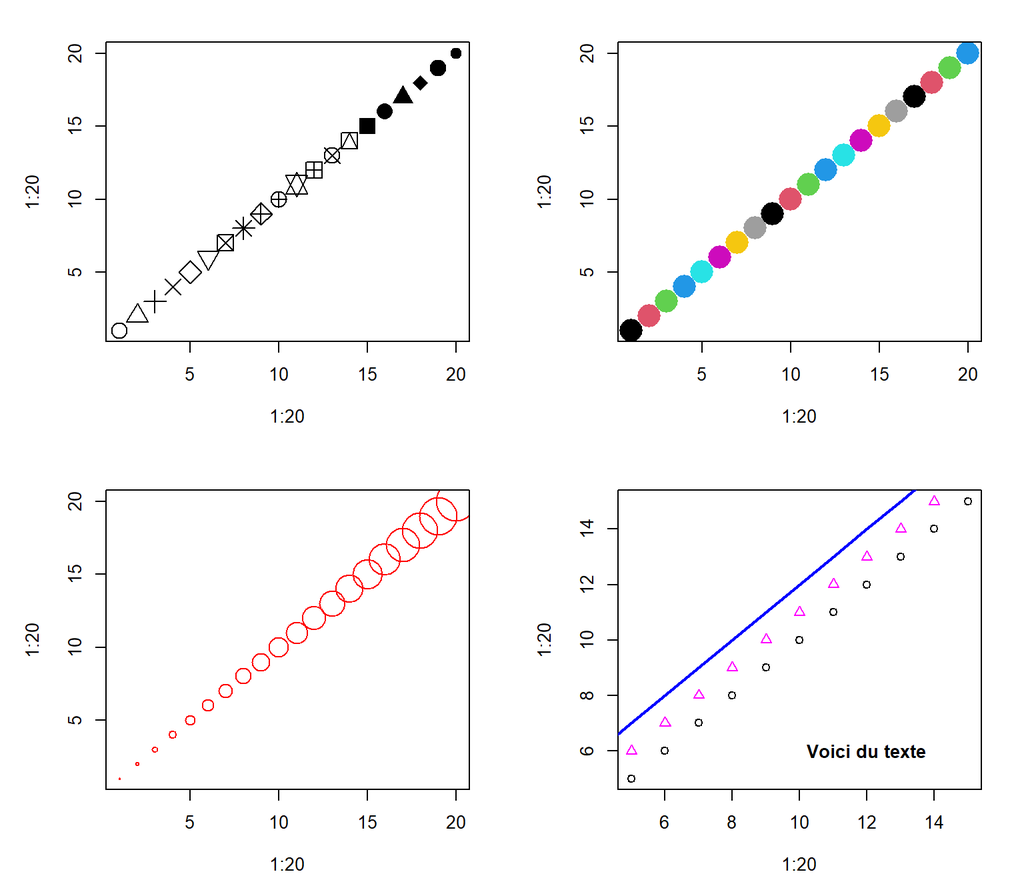

```r
par(mfrow = c(2, 2), mar = c(5, 5, 2, 2))

plot(1:20, 1:20, pch = 1:20, col = "black", cex = 2)  # graphique 1

plot(1:20, 1:20, pch = 16, col = 1:20, cex = 3)  # graphique 2

plot(1:20, 1:20, pch = 1, col = "red", cex = 1:20/4)  # graphique 3

plot(1:20, 1:20, xlim = c(5, 15), ylim = c(5, 15))  # graphique 4
points(1:20, 1:20 + 1, pch = 2, col = "magenta")
lines(1:20, 1:20 + 2, lwd = 2, lty = 1, col = "blue")
text(12, 6, labels = "Voici du texte", font = 2)
```

La fonction `plot` permet d’établir la fenêtre graphique. Par la suite, on peut ajouter des points, des lignes ou du texte à un graphique à l’aide des fonctions `points`, `lines` et `text`. Notez que ces fonctions ne permettent pas de créer ou d’ouvrir un graphique. Elles ne permettent que d’ajouter des éléments sur un graphique déjà exsitant. La fonction `legend` permet d’identifier des éléments sur un graphique.

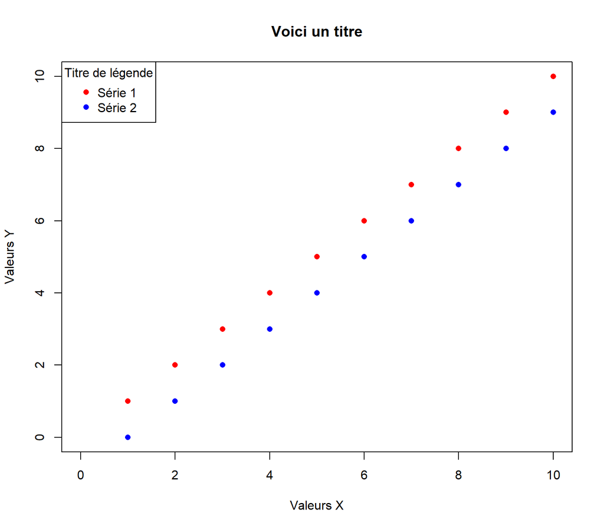

```r
par(mfrow = c(1, 1))

plot(1:10, 1:10, pch = 16, col = "red", xlim = c(0, 10), ylim = c(0, 10), xlab = "Valeurs X",
    ylab = "Valeurs Y", main = "Voici un titre")
points(1:10, 1:10 - 1, pch = 16, col = "blue")
legend("topleft", pch = 16, col = c("red", "blue"), legend = c("Série 1", "Série 2"),
    title = "Titre de légende")
```

## ggplot2

Il existe trois principaux systèmes dans R pour effectuer des graphiques. Les graphiques de bases sont représentés par les fonctions `plot`, `par` et les fonctions associées. Un autre système, passablement plus compliqué est le package [lattice](https://cran.r-project.org/web/packages/lattice/index.html) qui est souvent utilisé par d’autres fonctions. Un autre système, très populaire, est ggplot2 qui est de plus en plus utilisé. Un des principaux avantages de [ggplot2](http://ggplot2.org/) est que ce système permet de faire rapidement des graphiques plus attrayants comparativement aux graphiques de bases. La documentation concernant ggplot2 est également très détaillée et bien expliquée pour quiconque voudrait employer ce système. Toutefois, dans ce cours, nous n’utiliserons que les graphiques de bases puisque ceux-ci sont plus souvent utilisés par d’autres packages utiles en écologie.

## Exercice

Pour cet exercice, nous utiliserons une base de données (pines.csv) portant sur la croissance de jeunes Pins blancs (*Pinus strobus*) en lien avec avec l’utilisation d’un fertilisant, la déprédation par le Cerf de Virginie, la compétition avec la strate arbustive et l’espacement entre les individus. Cette base de données comporte plusieurs colonnes:

- **height**: hauteur de l’arbre
- **width**: largeur de l’arbre (maximale avec les branches)
- **height_ini**: hauteur initiale de l’arbre
- **row**: position de l’arbre selon les rangées de la plantation
- **col**: position de l’arbre selon les colonnes de la plantation
- **deer**: présence de broutage par le cerf (0 = non, 1 = oui)
- **fert**: utilisation d’un fertilisant (0 = non, 1 = oui)
- **spacing**: espacement avec les voisins (10 ou 15m)
- **cover**: recouvrement arbustif (0 = aucun, 1 = un peu, 2 = modéré, 3 = beaucoup)

Vous devrez réaliser plusieurs tâches et/ou répondre aux questions suivantes:

1. Importez la base de données.
2. Explorez et illustrez les liens entre la hauteur ou la largeur et les différentes variables explicatives (utilisez `boxplot`ainsi que la fonction `par` et son argument `mfrow` pour fractionner votre fenêtre graphique).
3. Effectuez une ANOVA afin d’étudier l’effet du broutement, de la couverture arbustive, du fertilisant ou de l’espacement sur la hauteur ou la largeur des individus. Pour ce faire, vous pouvez utiliser les fonctions `lm` ou `aov` en combinaison avec la fonction `summary`. Interprétez également les résultats.
4. Réalisez une carte schématique permettant d’illustrer la plantation et les traitements (espacement et fertilisant). Pour ce faire, vous devrez utiliser les fonctions `plot`, `legend` et possiblement `points`. Voux aurez également besoin des différents paramètres graphiques (arguments) décrits plus haut (`col`, `cex`, `pch`). La tâche pourrait aussi être facilitée en créant des groupes selon les différentes possibilités.

### Solution

#### 1.

En premier, on importe la base de données. On peut visualiser son contenu avec différentes fonctions comme `head` ou `summary`.

```r
d <- read.csv("U:/2018/2018/Ateliers/pines.csv", header = TRUE)
head(d)
```

```
##   height width height_ini row col deer fert spacing cover
## 1     NA    NA         NA   1   1   NA    0      15     0
## 2    362   162         14   1   2    1    0      15     2
## 3    442   250         17   1   3    0    0      15     1
## 4     NA    NA         NA   1   4   NA    0      15     0
## 5    369   176         24   1   5    0    0      15     2
## 6    365   215         22   1   6    0    0      15     1
```

#### 2.

Par la suite, on explore les liens entre les variables réponses (hauteur et largeur) et les variables explicatives. Pour ce faire, on peut utiliser des `boxplot` et créer une fenêtre graphique avec toutes les variables. On pourrait églement ajouter un titre général à nos graphiques en utilisant le paramètre graphique `oma` pour indiquer que nous voulons une marge externe (*outer margin*) et la fonction `mtext`.

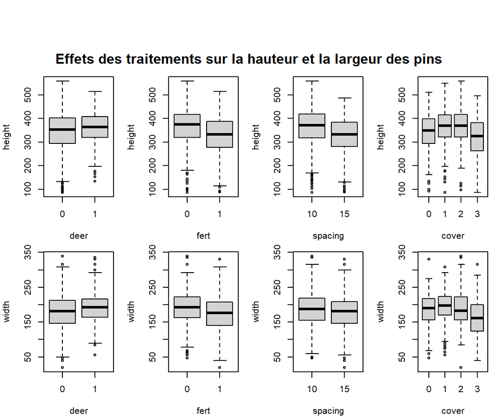

```r
par(mfrow = c(2, 4), mar = c(4, 4, 1, 1), oma = c(0, 0, 6, 0))

boxplot(height ~ deer, data = d, xlab = "deer", ylab = "height")
boxplot(height ~ fert, data = d, xlab = "fert", ylab = "height")
boxplot(height ~ spacing, data = d, xlab = "spacing", ylab = "height")
boxplot(height ~ cover, data = d, xlab = "cover", ylab = "height")
boxplot(width ~ deer, data = d, xlab = "deer", ylab = "width")
boxplot(width ~ fert, data = d, xlab = "fert", ylab = "width")
boxplot(width ~ spacing, data = d, xlab = "spacing", ylab = "width")
boxplot(width ~ cover, data = d, xlab = "cover", ylab = "width")

mtext("Effets des traitements sur la hauteur et la largeur des pins", side = 3, outer = TRUE,
    font = 2)
```

#### 3.

Pour effectuer une ANOVA, on peut utiliser la commande très générale `lm`. Avant de faire ceci, il faudra toutefois convertir nos variables numériques en facteurs, autrement, `lm` interprétera les différentes variables comme étant des variables numériques. Par exemple, dans la sortie suivante, on peut voir qu’il n’y a qu’une seule ligne par variable et on ne voit pas les niveaux des facteurs (1, 2 ou 3) collés aux noms des variables. Lorsque les étiquettes des niveaux des facteurs n’apparaissent pas à côté des noms des variables, cela indique généralement que les variables sont traitées comme étant numériques.

```r
m <- lm(height ~ deer + fert + spacing + cover, data = d)
summary(m)
```

```
##
## Call:
## lm(formula = height ~ deer + fert + spacing + cover, data = d)
##
## Residuals:
##      Min       1Q   Median       3Q      Max
## -289.527  -40.886    8.255   50.563  188.294
##
## Coefficients:
##             Estimate Std. Error t value Pr(>|t|)
## (Intercept)  453.269     14.356  31.574  < 2e-16 ***
## deer          18.963      5.774   3.284  0.00106 **
## fert         -38.191      5.307  -7.196 1.35e-12 ***
## spacing       -6.992      1.085  -6.444 1.94e-10 ***
## cover         -6.821      2.436  -2.800  0.00523 **
## ---
## Signif. codes:  0 '***' 0.001 '**' 0.01 '*' 0.05 '.' 0.1 ' ' 1
##
## Residual standard error: 77.84 on 858 degrees of freedom
##   (137 observations deleted due to missingness)
## Multiple R-squared:  0.1137, Adjusted R-squared:  0.1096
## F-statistic: 27.52 on 4 and 858 DF,  p-value: < 2.2e-16
```

Avant de faire notre modèle, on doit donc convertir nos variables en facteur en utilisant la fonction `as.factor`. Ce problème ne se poserait pas si nous avions des niveaux représentés par des caractères, puisque la fonction `read.csv` aurait automatiquement convertit ces valeurs en `factor`. Cela n’indique pas qu’il faut nécessairement utiliser des caractères pour désigner des facteurs, mais seulement qu’il faut porter attention aux niveaux identifiés par des entiers, ce qui est relativement commun dans les bases de données.

```r
d$deer <- as.factor(d$deer)
d$fert <- as.factor(d$fert)
d$spacing <- as.factor(d$spacing)
d$cover <- as.factor(d$cover)

m <- lm(height ~ deer + fert + spacing + cover, data = d)
summary(m)
```

```
##
## Call:
## lm(formula = height ~ deer + fert + spacing + cover, data = d)
##
## Residuals:
##      Min       1Q   Median       3Q      Max
## -301.289  -40.326    8.071   53.277  187.410
##
## Coefficients:
##             Estimate Std. Error t value Pr(>|t|)
## (Intercept)  366.819      6.583  55.718  < 2e-16 ***
## deer1         16.747      5.668   2.954  0.00322 **
## fert1        -34.710      5.219  -6.651 5.18e-11 ***
## spacing15    -35.660      5.307  -6.719 3.34e-11 ***
## cover1        21.470      7.276   2.951  0.00326 **
## cover2        21.452      7.397   2.900  0.00383 **
## cover3       -23.520      7.562  -3.110  0.00193 **
## ---
## Signif. codes:  0 '***' 0.001 '**' 0.01 '*' 0.05 '.' 0.1 ' ' 1
##
## Residual standard error: 76.13 on 856 degrees of freedom
##   (137 observations deleted due to missingness)
## Multiple R-squared:  0.1543, Adjusted R-squared:  0.1484
## F-statistic: 26.03 on 6 and 856 DF,  p-value: < 2.2e-16
```

On voit maintenant que les noms des coefficients ont changé puisqu’ils se rapportent maintenant aux niveaux des différents facteurs. Maintenant, si on interprète l’effet de nos variables, on voit que le broutement par le cerf à un effet positif sur la taille, mais l’utilisation du fertilisant et l’espacement entre les arbres ont tous deux un effet négatif sur la hauteur des arbres. Quant au recouvrement arbustif, des valeurs faibles ou modérées ont un effet positif comparativement à l’absence de recouvrement arbustif, mais un recouvrement élevé à un effet négatif comparativement à toutes les autres classe de recouvrement. Globablement, on peut aussi dire que nos variables expliquent une portion significative de la variance en hauteur, comme en témoigne le test du *F*. La proportion de variance expliquée (*R*<sup>*2*</sup>) est d’environ 15%. Comment interpréteriez vous ces résultats? Je vous laisse explorer l’effet des variables sur la largeur des arbres.

#### 4.

Pour construire une carte schématique de la plantation en fonction des traitements (fertilisation et espacement), nous pouvons utiliser les numéros de lignes et de colonnes de chacun des arbres. Il y a plusieurs options pour associer des symboles aux traitements. À ce stade, le plus simple est probablement de créer différents sous-ensembles et d’ajouter les points sur un graphique déjà existant. En illustrant la localisation de tous les arbres en premier, on s’assure que la fenêtre graphique couvrira l’ensemble de la plantation. Pour éviter que des points se tracent avec la fonction `plot` initiale, on peut soit utiliser la couleur blanche avec l’argument `col = "white"` ou encore utiliser l’argument `type = "n"`. Ceci produit le graphique, mais sans tracer les points associés. On peut également utiliser la fonction `legend` pour identifier les différentes possibilités. Pour éviter d’écrire des commandes trop longues, j’utilise un vecteur `leg` où j’écris le texte qui composera la légende.

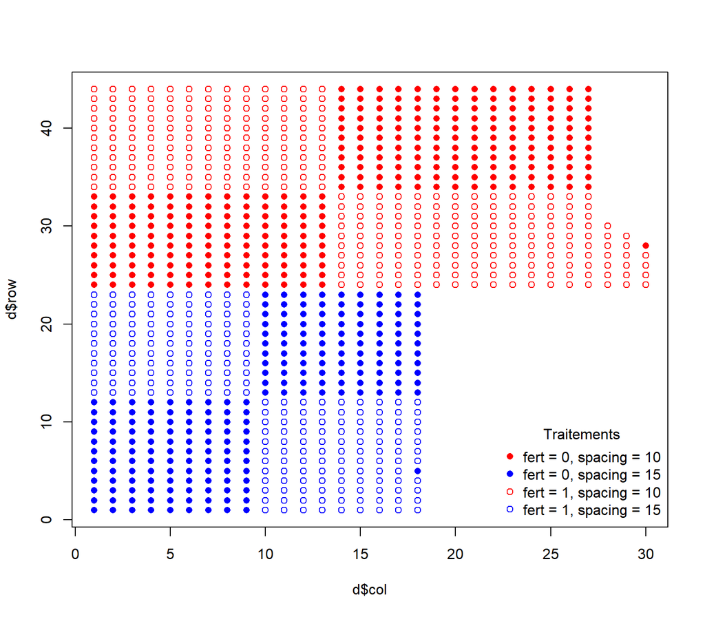

```r
d1 <- d[d$fert == 0 & d$spacing == 10, ]
d2 <- d[d$fert == 0 & d$spacing == 15, ]
d3 <- d[d$fert == 1 & d$spacing == 10, ]
d4 <- d[d$fert == 1 & d$spacing == 15, ]

plot(d$col, d$row, type = "n")

points(d1$col, d1$row, col = "red", pch = 16)
points(d2$col, d2$row, col = "blue", pch = 16)
points(d3$col, d3$row, col = "red", pch = 1)
points(d4$col, d4$row, col = "blue", pch = 1)

leg <- c("fert = 0, spacing = 10", "fert = 0, spacing = 15", "fert = 1, spacing = 10",
    "fert = 1, spacing = 15")

legend("bottomright", pch = c(16, 16, 1, 1), col = c("red", "blue", "red", "blue"),
    legend = leg, bty = "n", title = "Traitements")
```

# Atelier 3

## Retour

### L’argument `sep`

L’argument `sep` permet de spécifier aux fonctionx `read.table` ou `read.csv` quel est le séparateur utilisé dans un fichier *.csv*. Par défaut, `sep = ","` dans la fonction `read.csv`. Si vous spécifiez `sep = ";"`, alors qu’en réalité vos données sont séparées par une virgule, vos données seront lues et considérées comme faisant parti d’une seule colonne. Consultez la page d’aide sur la fonction `?read.table` pour plus de détails.

### Vecteurs vs `data.frame`

Plusieurs ont été tenté de renommer les colonnes et de se créer des vecteurs indépendants pour ensuite les soumettre aux fonctions `boxplot` ou `lm`. Ceci est généralement à éviter. Premièrement, cela implique plus de travail et plus de lignes de codes. Ensuite, en créant des vecteurs indépendants, on court le risque de perdre l’ordre selon lequel les valeurs sont emmagasinées ou d’avoir des vecteurs de longueurs différentes si on décide de supprimer les valeurs manquantes dans certains vecteurs, mais qu’on oublie de le faire dans d’autres. La meilleure façon de procéder est de faire usage de l’argument `data` lorsque celui-ci est disponible et donc d’utiliser notre `data.frame`. De plus, lorsque l’argument `data` est utilié, il devient inutile d’utiliser le `$` pour indiquer nos variables. Par exemple, les deux lignes suivantes sont équivalentes.

```r
boxplot(d$height ~ d$deer, data = d)
boxplot(height ~ deer, data = d)
```

### Les formules

Les formules sont beaucoup utilisées dans R, particulièrement lorsqu’on fait des modèles. Une formule s’écrit généralement de cette façon: `réponse ~ var1 + var2`. Le symble `~` veut souvent dire “expliqué par” ou “groupé par”. Par exemple, le premier argument à la fonction `boxplot` est une formule. Les arguments donnés sous cette forme sont généralement accompagnés d’un argument `data`.

### `boxplot` avec `num ~ num`

Les boxplots sont faits pour étudier les valeurs de variables quantitatives en fonction de variables catégoriques. Si vous faites un boxplot pour deux valeurs numériques, vous obtiendrez une boîte pour chacune des valeurs uniques de la variable “explicative”, ce qui n’est pas très utile.

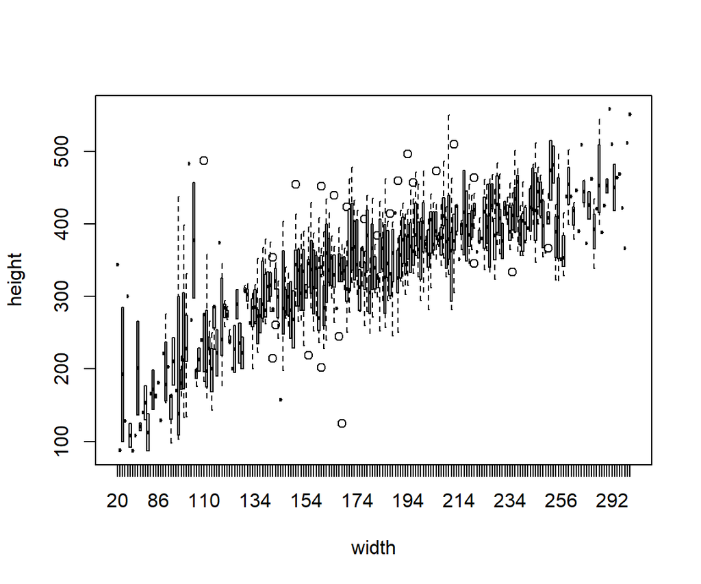

```r
boxplot(height ~ width, data = d)
```

### Transformation en facteurs

La plupart des fonctions servant à faire des modèles vont exiger que les variables catégoriques soient préalablement transformées en facteur. Dans certains cas, les variables caractères seront converties en facteurs par la fonction utilisée. Cependant, si vos facteurs sont représentés par des valeurs numériques, il est impératif de les transformer en facteurs, autrement, ils seront considérés comme des variables numériques et vos analyses seront erronées.

## Mieux comprendre son modèle avec `predict`

La fonction `predict` est utilisée pour générer des prédictions à partir d’un modèle déjà existant. Par exemple, voici comment utiliser cette fonction avec un modèle fictif. Premièrement, créeons un modèle fictif avec une variable explicative numérique (x) et une variable explicative catégorique (sexe).

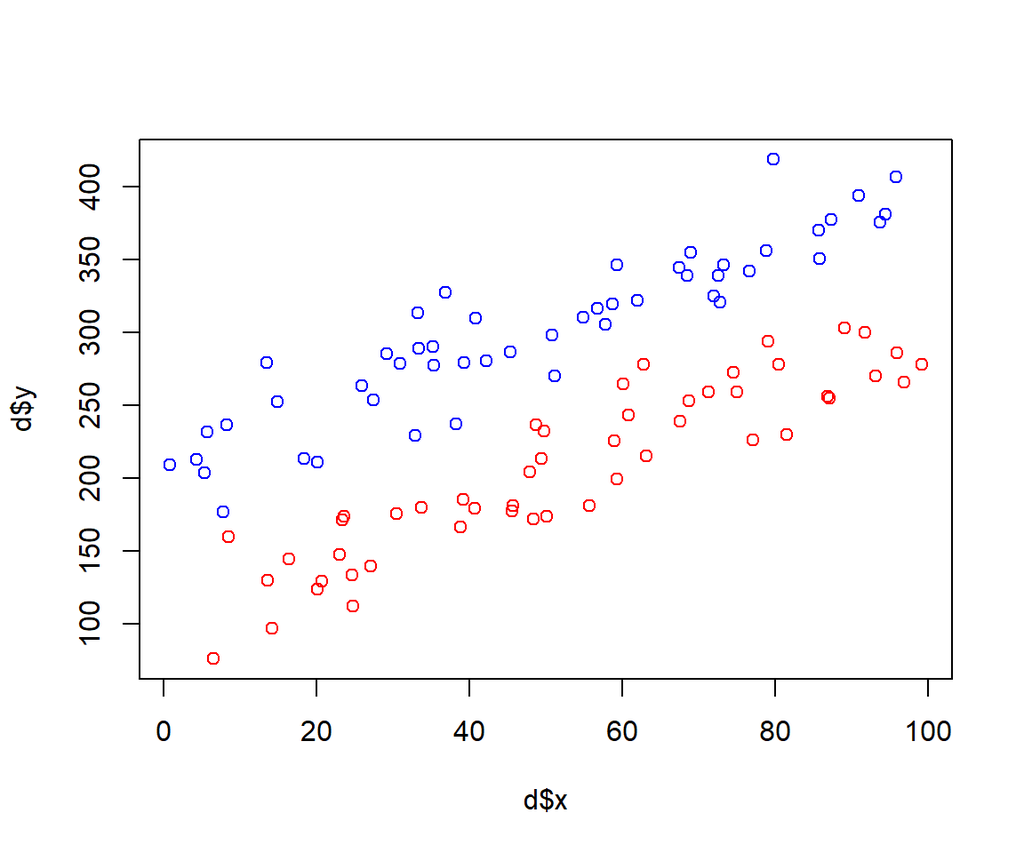

```r
n <- 100
x <- runif(n, min = 0, max = 100)
val <- rep(c(0, 100), each = n/2)
sexe <- rep(c("m", "f"), each = n/2)
y <- 100 + 2 * x + val + rnorm(n, mean = 0, sd = 20)
d <- data.frame(y, x, sexe)
plot(d$x, d$y, col = ifelse(d$sexe == "m", "red", "blue"))
```

Voici l’estimation des paramètres du modèle avec la fonction `lm`.

```r
m <- lm(y ~ x + sexe, data = d)
summary(m)
```

```
##
## Call:
## lm(formula = y ~ x + sexe, data = d)
##
## Residuals:
##     Min      1Q  Median      3Q     Max
## -43.988 -15.950  -1.214  15.215  56.909
##
## Coefficients:
##               Estimate Std. Error t value Pr(>|t|)
## (Intercept)  205.55529    5.35425   38.39   <2e-16 ***
## x              1.96179    0.08649   22.68   <2e-16 ***
## sexem       -102.47610    4.67024  -21.94   <2e-16 ***
## ---
## Signif. codes:  0 '***' 0.001 '**' 0.01 '*' 0.05 '.' 0.1 ' ' 1
##
## Residual standard error: 23.28 on 97 degrees of freedom
## Multiple R-squared:  0.905,  Adjusted R-squared:  0.9031
## F-statistic: 462.1 on 2 and 97 DF,  p-value: < 2.2e-16
```

Avec `predict`, on soumet des données à notre modèle pour générer des prédictions. Ici, on demande de faire varier x de 0 à 100 et on fixe le facteur sexe à “m”. On met ces valeurs dans un `data.frame` qui sera utilisé par `predict` pour générer les prédictions. Ensuite, on traces ces valeurs prédites à l’aide fonction `lines`.

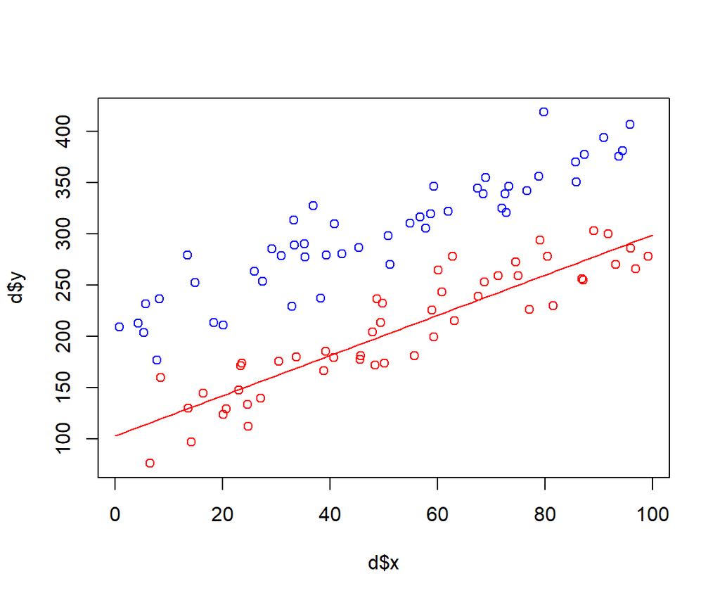

```r
dat <- data.frame(x = 0:100, sexe = "m")
p <- predict(m, newdata = dat)

plot(d$x, d$y, col = ifelse(d$sexe == "m", "red", "blue"))
lines(0:100, p, col = "red")
```

## Exercices

### Les coûts de la reproduction

Le premier exercice consiste à étudier l’effet de la reproduction sur la longévité chez les mâles de drosophiles (une espèce de mouche). L’idée est que la reproduction a probablement un coût et ce coût pourrait être observé sur la longévité des individus; les mâles étant davantage exposés à la reproduction devraient vivre moins longtemps. Voici la base de données flies.csv. Cinq traitements ont été utilisés. Les mâles ont été mis en présence de 0, 1 ou 8 femelles et celles-ci étaient soient vierges, soient gestantes (donc non-réceptives à l’accouplement). D’autres variables ont été mesurées, notamment la longueur du thorax des mâles et la proportion du temps passé à dormir. Dans cet exercice vous devez:

1. Explorez les données, i.e. faire des graphiques permettant d’illustrer la distribution ou les liens entres les différentes variables.
2. Déterminez si la longévité est influencée par le traitement.
3. Vérifiez les conditions d’applications avec la fonction `plot` appliquée sur votre modèle.

#### Solution

On importe d’abord le fichier et on effectue quelques graphiques pour explorer les données.

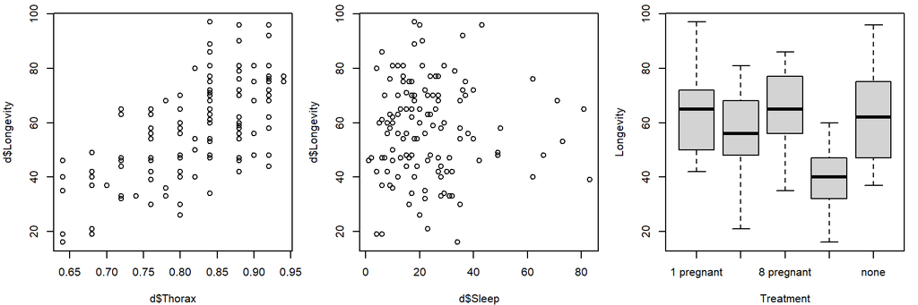

```r
d <- read.csv("https://raw.githubusercontent.com/frousseu/ECL749/master/data/flies.csv")
par(mfrow = c(1, 3), mar = c(4, 4, 1, 1))
plot(d$Thorax, d$Longevity)
plot(d$Sleep, d$Longevity)
boxplot(Longevity ~ Treatment, data = d)
```

La longévité semble beaucoup plus faible pour les mâles exposés à plusieurs femelles réceptives. Aussi, la taille du thorax semble avoir un effet positif très fort sur la longévité. Il serait donc important d’inclure cette variable comme contrôle (même si elle n’est pas spécifiquement d’intérêt) afin de réduire le bruit dans nos observations. La proportion du temps passé à dormir ne semble pas avoir d’effet sur la longévité, mais vérifions tout de même ceci en incluant ces variables dans un modèle.

```r
m <- lm(Longevity ~ Treatment + Thorax + Sleep, data = d)
summary(m)
```

```
##
## Call:
## lm(formula = Longevity ~ Treatment + Thorax + Sleep, data = d)
##
## Residuals:
##     Min      1Q  Median      3Q     Max
## -27.331  -7.520  -0.632   6.462  29.760
##
## Coefficients:
##                      Estimate Std. Error t value Pr(>|t|)
## (Intercept)         -46.27094   10.48525  -4.413 2.27e-05 ***
## Treatment1 virgin    -9.55148    2.96946  -3.217  0.00167 **
## Treatment8 pregnant   1.37939    2.97574   0.464  0.64383
## Treatment8 virgin   -22.83507    2.98667  -7.646 6.13e-12 ***
## Treatmentnone        -2.85763    2.97135  -0.962  0.33815
## Thorax              136.79061   12.42682  11.008  < 2e-16 ***
## Sleep                -0.07738    0.05985  -1.293  0.19854
## ---
## Signif. codes:  0 '***' 0.001 '**' 0.01 '*' 0.05 '.' 0.1 ' ' 1
##
## Residual standard error: 10.48 on 118 degrees of freedom
## Multiple R-squared:  0.6612, Adjusted R-squared:  0.6439
## F-statistic: 38.38 on 6 and 118 DF,  p-value: < 2.2e-16
```

On a un effet positif du thorax sur la longévité et un effet du traitement sur la longévité. Les mâles exposés à des femelles réceptives vivent moins longtemps que les mâles moins ou pas exposés et ceci est particulièrement vrai chez les mâles fortement exposés. On pourrait également comparer les traitements entre eux avec un test de comparaison multiple. Puisque nous avons utilisé la fonction `lm` nous ne pouvons pas prendre `TukeyHSD` qui ne fonctionne qu’avec `aov`, mais nous pouvons prendre la fonction plus générale `glht` dans le package [multcomp](https://cran.r-project.org/web/packages/multcomp/index.html).

```r
library(multcomp)
```

[output not shown]

```r
summary(glht(m, linfct = mcp(Treatment = "Tukey")))
```

[output not shown]

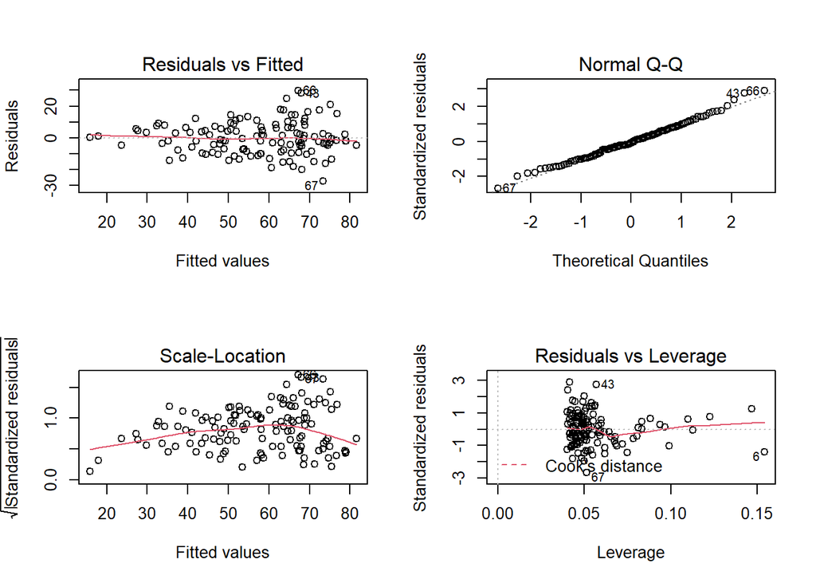

```r
par(mfrow = c(2, 2))
plot(m)
```

Pour mieux illustrer les prédictions de notre modèle, utilisons un graphique à bande avec des intervalles de confiance sur les prédictions. Je vais vous laisser étudier le code. Notez l’utilisation d’une boucle à la fin du code. Ici, *i* prendra toute les valeurs correspondant aux lignes du tableau de prédictions.

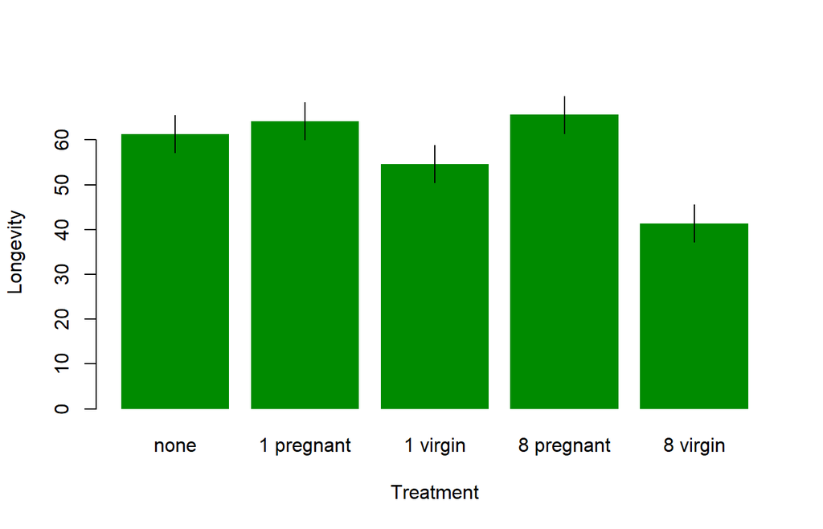

```r
# On produit un tableau de valeurs avec lequel on veut générer des prédictions
dat <- data.frame(Treatment = unique(d$Treatment), Thorax = mean(d$Thorax), Sleep = mean(d$Sleep))

# On organise nos valeurs selon un ordre logique
dat <- dat[c(2, 3, 4, 1, 5), ]

# On prédit nos valeurs avec un intervalle de confiance
p <- predict(m, newdata = dat, interval = "confidence")

# On produit un barplot
b <- barplot(p[, 1], names.arg = dat$Treatment, col = "green4", border = NA, ylim = c(0,
    max(p)), ylab = "Longevity", xlab = "Treatment")

# On ajoute les bornes inférieures et supérieurs des intervalles de confiance
for (i in 1:nrow(dat)) {
    lines(rep(b[i, 1], 2), c(p[i, 2], p[i, 3]))
}
```

### Tendances dans la phénologie de nidification

Pour ce deuxième exercice, on veut savoir s’il y a des changements dans les dates de pontes à travers les années chez une espèce d’oiseau (la Paruline jaune). Avec les changements climatiques, on pourrait s’attendre à ce que les oiseaux nichent de plus en plus tôt à chaque saison. Voici la base de données warblers.csv. Est-ce que ces changements sont les mêmes d’une province à l’autre? La colonne *jul* donne le jour julien de la date de ponte du premier oeuf (nb de jour depuis le 1er janvier). Dans cet exercice, vous devez:

1. Explorez les données (i.e., familiarisez-vous avec la base de données).
2. Déterminer s’il y a des changements dans les dates de ponte au cours des dernières années et si ces changements sont différents d’une province à l’autre.
3. Illustrez les prédictions de votre modèle en utilisant la fonction `predict`. Pour ce faire, vous devrez utiliser l’argument `newdata` avec lequel vous soumettrez des observations à votre modèle.
4. Est-ce que les suppositions de base sont respectées? Est-ce que vous voyez des choses à améliorer avec cette analyse?

#### Solution

Chargeons d’abord les données et déterminons d’abord combien il y a d’observations par province et par année.

```r
d <- read.csv("https://raw.githubusercontent.com/frousseu/ECL749/master/data/warblers.csv")

table(d$prov)
```

```
##
##   NB   ON   QC
##  200 1700  185
```

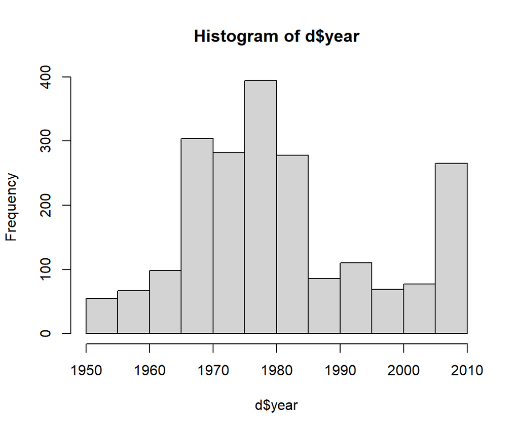

```r
hist(d$year)
```

Illustrons les données en lien avec notre question.

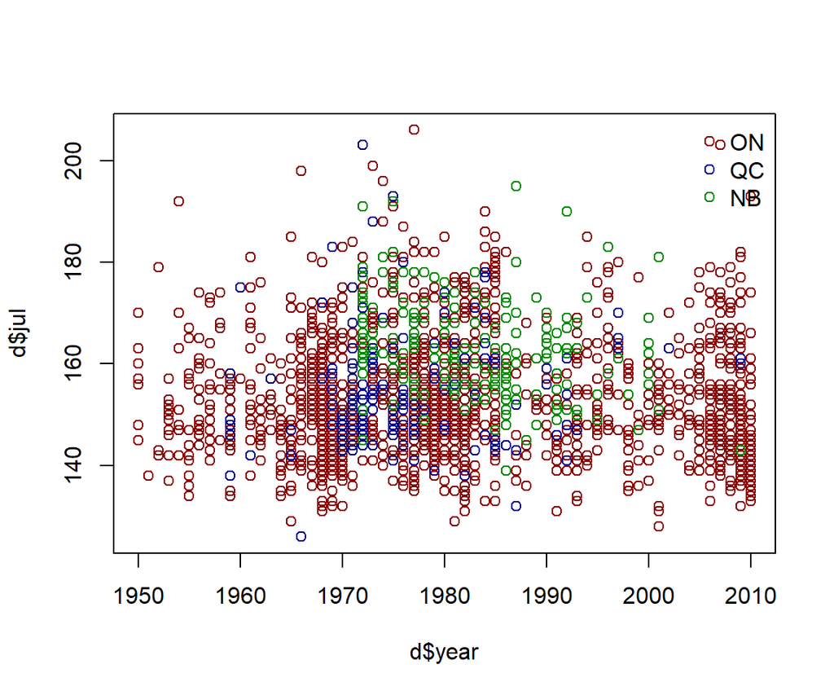

```r
plot(d$year, d$jul, type = "n")
points(d$year[d$prov == "ON"], d$jul[d$prov == "ON"], col = "darkred")
points(d$year[d$prov == "QC"], d$jul[d$prov == "QC"], col = "darkblue")
points(d$year[d$prov == "NB"], d$jul[d$prov == "NB"], col = "green4")
legend("topright", pch = 1, col = c("darkred", "darkblue", "green4"), legend = c("ON",
    "QC", "NB"), bty = "n")
```

Pour déterminer si les changements dans la date de ponte dépendent de la province, il faut utiliser une interaction entre l’année et la province. Pour ce faire, on peut écrire notre modèle de cette façon.

```r
m <- lm(jul ~ year * prov, data = d)
summary(m)
```

```
##
## Call:
## lm(formula = jul ~ year * prov, data = d)
##
## Residuals:
##     Min      1Q  Median      3Q     Max
## -27.172  -7.785  -1.991   5.844  53.092
##
## Coefficients:
##              Estimate Std. Error t value Pr(>|t|)
## (Intercept)  811.2265   200.6610   4.043 5.47e-05 ***
## year          -0.3270     0.1012  -3.232 0.001251 **
## provON      -576.8370   203.5185  -2.834 0.004637 **
## provQC      -954.5381   267.2647  -3.572 0.000363 ***
## year:provON    0.2858     0.1026   2.784 0.005410 **
## year:provQC    0.4778     0.1350   3.540 0.000409 ***
## ---
## Signif. codes:  0 '***' 0.001 '**' 0.01 '*' 0.05 '.' 0.1 ' ' 1
##
## Residual standard error: 11.22 on 2079 degrees of freedom
## Multiple R-squared:  0.07336,    Adjusted R-squared:  0.07114
## F-statistic: 32.92 on 5 and 2079 DF,  p-value: < 2.2e-16
```

On a effectivement une interaction significative entre la province et l’année ce qui nous indique que les changements dans la date de ponte ne sont pas les mêmes d’une province à l’autre. Cependant, pour bien interpréter cette interaction, il est préférable d’utiliser un graphique illustrant les prédictions afin d’éviter la gymnastique difficile du calcul avec les coefficients du modèle.

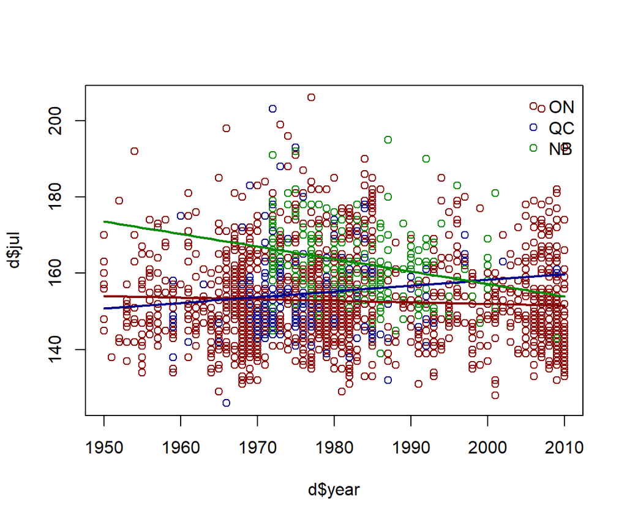

```r
dat <- expand.grid(year = min(d$year):max(d$year), prov = c("ON", "QC", "NB"))
p <- predict(m, dat)
dat$p <- p

plot(d$year, d$jul, type = "n")
points(d$year[d$prov == "ON"], d$jul[d$prov == "ON"], col = "darkred")
points(d$year[d$prov == "QC"], d$jul[d$prov == "QC"], col = "darkblue")
points(d$year[d$prov == "NB"], d$jul[d$prov == "NB"], col = "green4")
legend("topright", pch = 1, col = c("darkred", "darkblue", "green4"), legend = c("ON",
    "QC", "NB"), bty = "n")

lines(p ~ year, data = dat[dat$prov == "ON", ], col = "darkred", lwd = 2)
lines(p ~ year, data = dat[dat$prov == "QC", ], col = "darkblue", lwd = 2)
lines(p ~ year, data = dat[dat$prov == "NB", ], col = "green4", lwd = 2)
```

# Atelier 4

Pour cet atelier, vous apprendrez à utiliser différentes fonctions pour explorer, manipuler et mettre en forme une base données. Cette base de données contient des observations de nombres d’individus pour 3 espèces d’oiseaux (Paruline couronnée (PACO), Carouge à épaulettes (CAEP) et Moineau domestique (MODO)) soumises lors de sorties sur le terrain. À chaque fois qu’un observateur va sur le terrain, un feuillet est soumis où le nombre d’individus de chaque espèce est noté. Nous avons ces informations pour les trois espèces d’oiseaux. Ces feuillets sont rattachés à différentes cellules ayant chacune un identifiant et des coordonnées. Vous devrez également intégrer des données d’habitat associées à chacune de ces cellules. Voici le contenu de ces deux bases de données ainsi que les tâches à accomplir.

[**cell_oiseaux**](https://raw.githubusercontent.com/frousseu/ECL749/master/data/cell_oiseaux.csv)

- **cell**: identifiant de la cellule
- **Latitude**: latitude
- **Longitude**: longitude
- **PACO**: nb d’individus pour la Paruline couronnée
- **CAEP**: nb d’individus pour le Carouge à épaulettes
- **MODO**: nb d’individus pour Moineau domestique
- **day**: date
- **month**: mois
- **year**: année

[**cell_milieux**](https://raw.githubusercontent.com/frousseu/ECL749/master/data/cell_milieux.csv)

- **cell**: identifiant de la cellule
- **%MilieuNaturel**: % de milieus naturels (forêt, milieux humides, etc.)
- **%BatiCommercial**: % de milieux commerciaux
- **%BatiResidentiel**: % de milieux résidentiels
- **%Agricole**: % de milieux agricoles
1. Importez les bases de données.
2. Créez une colonne nommée “date” avec le format “2019-02-13” en utilisant la fonction `as.Date`. Vous aurez préalablement à assembler vos valeurs pour obtenir le format voulu à l’aide de la fonction `paste` qui permet de coller ensemble des chaînes de caractères. Voici des exemples d’utilisation de ces deux fonctions.

```r
paste(1:5, c("a", "b", "c", "d", "e"), sep = "_")
```

```
## [1] "1_a" "2_b" "3_c" "4_d" "5_e"
```

```r
x <- as.Date(c("2019-02-12", "2019-02-13"))
x
```

```
## [1] "2019-02-12" "2019-02-13"
```

```r
class(x)
```

```
## [1] "Date"
```

De façon interne, le format `Date` est stocké comme un entier représentant le nombre de jours depuis 1970-01-01.

```r
as.integer(as.Date(c("1970-01-01", "1971-01-01")))
```

```
## [1]   0 365
```

3. Ordonnez votre tableau de données par date à l’aide de la fonction `order`. Cette fonction permet de réorganiser les lignes en fonction de l’ordre des éléments choisis. Voici un exemple avec le jeu de données `iris` inclus dans R.

```r
x <- iris[order(iris$Species, iris$Petal.Length), ]
head(x, 5)
tail(x, 5)
```

```
##    Sepal.Length Sepal.Width Petal.Length Petal.Width Species
## 23          4.6         3.6          1.0         0.2  setosa
## 14          4.3         3.0          1.1         0.1  setosa
## 15          5.8         4.0          1.2         0.2  setosa
## 36          5.0         3.2          1.2         0.2  setosa
## 3           4.7         3.2          1.3         0.2  setosa
##     Sepal.Length Sepal.Width Petal.Length Petal.Width   Species
## 132          7.9         3.8          6.4         2.0 virginica
## 106          7.6         3.0          6.6         2.1 virginica
## 118          7.7         3.8          6.7         2.2 virginica
## 123          7.7         2.8          6.7         2.0 virginica
## 119          7.7         2.6          6.9         2.3 virginica
```

4. Par erreur, des valeurs de NA ont été utilisées dans certains cas lorsque le nombre d’individus rencontrés était de 0. Remplacez ces valeurs de `NA` par des 0 dans les nombres d’individus. Ici, vous aurez besoin des fonctions `ifelse` et `is.na`.

Par exemple, voici une utilisation de ces deux fonctions.

```r
v <- c(1, 2, 3, NA)
is.na(v)
```

```
## [1] FALSE FALSE FALSE  TRUE
```

```r
v <- ifelse(is.na(v), 0, v)
v
```

```
## [1] 1 2 3 0
```

5. Illustrez pour une espèce donnée le nb d’individus vu à chaque jour. Pour ce faire, vous devrez utiliser votre date comme l’élément variant selon l’axe des X (sous le format `Date`). La date sera convertie en valeur numérique et les étiquettes s’ajusteront au format `Date`.
6. Illustrez la localisation des différentes cellules dans un graphique. Vous remarquerez que les coordonnées contiennent des virgules au lieu des points. Il vous faudra donc transformer ces virgules en points avec la fonction `gsub` et ensuite transformer ce dernier résultat en valeur numérique avec la fonction `as.numeric`. Voici un exemple d’utilisation de la fonction `gsub`. Cette fonction permet de remplacer un caractère par un autre dans un vecteur de caractères.

```r
x <- c("45,67", "45,98")
y <- gsub(",", ".", x)
y
```

```
## [1] "45.67" "45.98"
```

```r
y <- as.numeric(y)
y
```

```
## [1] 45.67 45.98
```

Puisqu’il y a plusieurs lignes de données pour chaque cellule, il serait préférable de ne conserver qu’une seule ligne par cellule pour illustrer la localisation de chaque cellule afin d’éviter de tracer trop de points inutilement. Pour ne conserver qu’une seule ligne par cellule, vous pouvez utiliser la fonction `unique` qui permet de conserver les valeurs qui ne sont pas des doublons. Voici un exemple d’utilisation de la fonction `unique` appliquée sur un vecteur et sur un `data.frame`. Avec cette fonction, vous pourriez vous créer un `data.frame` ne contenant que les coordonnées des différentes cellules.

```r
x <- c("a", "a", "a", "b", "b", "c")
unique(x)
```

```
## [1] "a" "b" "c"
```

```r
y <- c(1, 2, 1, 3, 3, 3)
d <- data.frame(x, y)
d
```

```
##   x y
## 1 a 1
## 2 a 2
## 3 a 1
## 4 b 3
## 5 b 3
## 6 c 3
```

```r
unique(d)
```

```
##   x y
## 1 a 1
## 2 a 2
## 4 b 3
## 6 c 3
```

7. À l’aide de vos coordonées, illustrez les abondances soumises d’une de vos espèces d’oiseaux en faisant varier la taille de vos points.
8. Pour chaque espèce, quelle est la proportion de feuillets contenant au moins un individu?
9. Votre graphique précédent illustre chacune des mentions ce qui peut rendre difficile l’appréciation de l’abondance de l’espèce à travers les différentes régions. Afin de résumer cette information par cellule, calculez le nombre moyen d’individus mentionnés par cellule et illustrez plutôt ces valeurs. Il y a plusieurs façons de faire ce calcul dans R. La façon de base est probablement d’employer la fonction `aggregate` avec sa version utilisant les formules. Voici un exemple d’utilisation de cette fonction avec le jeu de données `iris`.

```r
head(iris)
```

```
##   Sepal.Length Sepal.Width Petal.Length Petal.Width Species
## 1          5.1         3.5          1.4         0.2  setosa
## 2          4.9         3.0          1.4         0.2  setosa
## 3          4.7         3.2          1.3         0.2  setosa
## 4          4.6         3.1          1.5         0.2  setosa
## 5          5.0         3.6          1.4         0.2  setosa
## 6          5.4         3.9          1.7         0.4  setosa
```

```r
aggregate(Petal.Length ~ Species, data = iris, FUN = mean)
```

```
##      Species Petal.Length
## 1     setosa        1.462
## 2 versicolor        4.260
## 3  virginica        5.552
```

```r
aggregate(. ~ Species, data = iris, FUN = mean)
```

```
##      Species Sepal.Length Sepal.Width Petal.Length Petal.Width
## 1     setosa        5.006       3.428        1.462       0.246
## 2 versicolor        5.936       2.770        4.260       1.326
## 3  virginica        6.588       2.974        5.552       2.026
```

10. Quel est le nombre moyen de Parulines couronnées mentionné par feuillet à chaque mois? Illustrez ces valeurs à l’aide de la fonction `barplot`.
11. Des données de types de milieux ont été extraites pour chaque cellule, mais ces données se trouvent dans une autre base de données. Ajoutez ces données de types de milieux à vos données d’observations. Pour ce faire, vous devrez utiliser la fonction `merge`. Au préalable, changez les noms de colonnes des types de milieux pour éliminer les “%” qui risqueraient de causer des difficultés lors de la création d’éventuels modèles. Pour ce faire, vous pouvez utiliser la fonction `names` avec l’indexage et la fonction `which`. En voici un exemple. La fonction `which` identifie les positions dans le vecteur où une ou des conditions sont rencontrées.

```r
x <- iris
head(x)
```

```
##   Sepal.Length Sepal.Width Petal.Length Petal.Width Species
## 1          5.1         3.5          1.4         0.2  setosa
## 2          4.9         3.0          1.4         0.2  setosa
## 3          4.7         3.2          1.3         0.2  setosa
## 4          4.6         3.1          1.5         0.2  setosa
## 5          5.0         3.6          1.4         0.2  setosa
## 6          5.4         3.9          1.7         0.4  setosa
```

```r
names(x)
```

```
## [1] "Sepal.Length" "Sepal.Width"  "Petal.Length" "Petal.Width"  "Species"
```

```r
w <- which(names(x) == "Species")
w
```

```
## [1] 5
```

```r
names(x)[w] <- "espèces"
head(x)
```

```
##   Sepal.Length Sepal.Width Petal.Length Petal.Width espèces
## 1          5.1         3.5          1.4         0.2  setosa
## 2          4.9         3.0          1.4         0.2  setosa
## 3          4.7         3.2          1.3         0.2  setosa
## 4          4.6         3.1          1.5         0.2  setosa
## 5          5.0         3.6          1.4         0.2  setosa
## 6          5.4         3.9          1.7         0.4  setosa
```

12. Ajoutez un nouveau type de milieu (urbain) en additionnant les superficies occupées par les milieux résidentiels et les milieux commerciaux.
13. Illustrez dans une même fenêtre graphique les valeurs de % de types de milieux pour chaque type. Cela correspond à la création de 4 cartes pour illustrer chaque type de milieu.

### Solution

```r
o <- read.csv("https://raw.githubusercontent.com/frousseu/ECL749/master/data/cell_oiseaux.csv",
    sep = ";", header = TRUE)
h <- read.csv("https://raw.githubusercontent.com/frousseu/ECL749/master/data/cell_milieux.csv",
    sep = ";", header = TRUE)
```

```r
o$date <- as.Date(paste(o$year, o$month, o$day, sep = "-"))
```

```r
o <- o[order(o$date), ]
```

Vous pouvez vérifier s’il y a des `NA` dans les différentes colonnes avec la fonction `summary` ou en utilisant `table(is.na(d$PACO))` pour une colonne en particulier. Il semble y avoir des `NA` uniquement dans la colonne `PACO`.

```r
o$PACO <- ifelse(is.na(o$PACO), 0, o$PACO)
```

Ce graphique nous permet de voir qu’il y a qqch qui cloche avec les abondances de CAEP et PACO… En bonus, je rajoute sur l’axe des X du dernier graphique un peu plus de précision

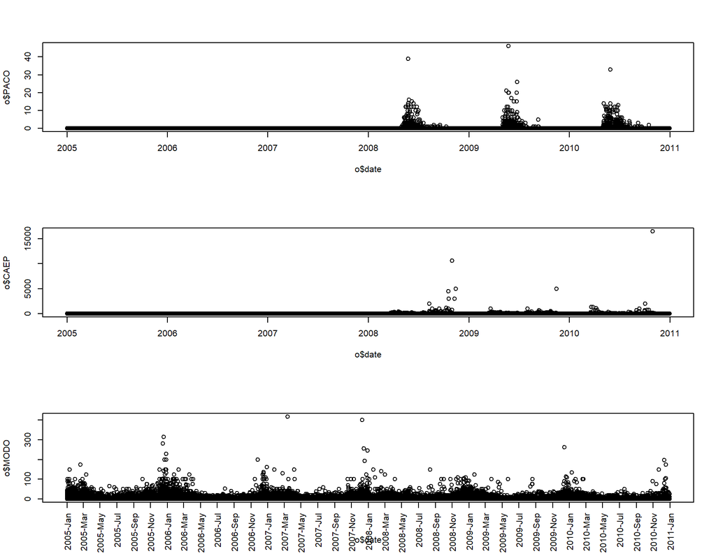

```r
par(mfrow = c(3, 1))
plot(o$date, o$PACO)
plot(o$date, o$CAEP)
plot(o$date, o$MODO, xaxt = "n")
x <- seq.Date(as.Date("2005-01-01"), as.Date("2011-01-01"), by = "2 month")
axis.Date(side = 1, x, at = x, format = "%Y-%b", las = 2)
```

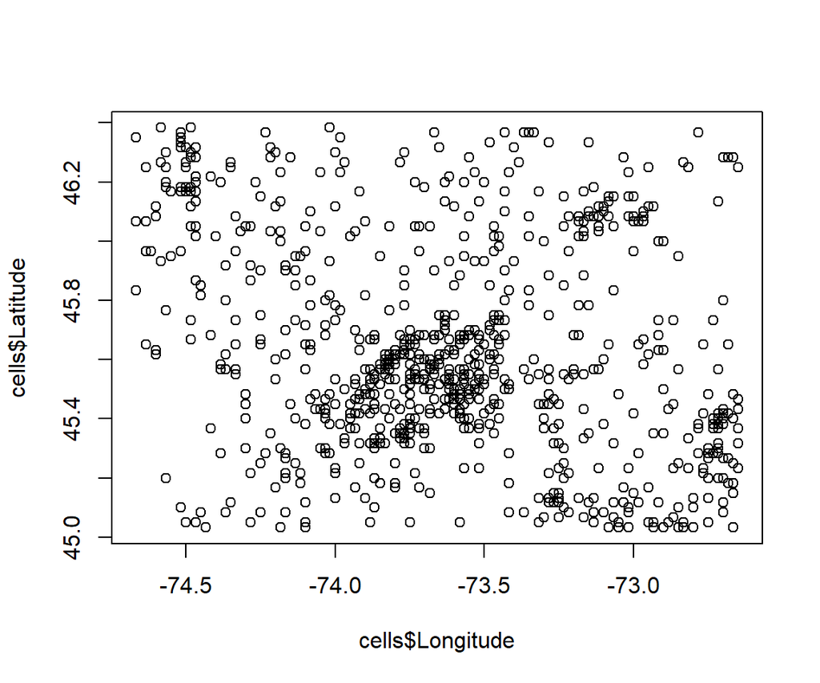

```r
o$Longitude <- as.numeric(gsub(",", ".", o$Longitude))
o$Latitude <- as.numeric(gsub(",", ".", o$Latitude))

cells <- unique(o[, c("cell", "Longitude", "Latitude")])

par(mfrow = c(1, 1))
plot(cells$Longitude, cells$Latitude)
```

Pour ce faire, le plus simple est d’utiliser l’argument `cex` de la fonction `plot` avec les abondances d’oiseaux transformées ou divisées par une certaine valeurs. Ces valeurs indiqueront la surface occupée par chaque point et par défaut, cette surface est de 1. Il faut donc réduire certaines valeurs pour éviter d’avoir des points trop grands. Une transformation `log` permettrait d’écraser les valeurs très grandes. Vous pourriez aussi divisier vos valeurs par un facteur approprié. Il est également possible d’utiliser des points pleins avec l’argument `pch` et la fonction `gray` avec laquelle on peu spécifier un gris plus ou moins transparent.

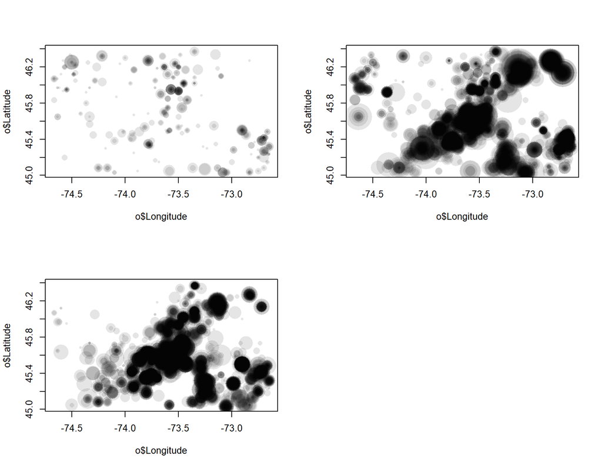

```r
par(mfrow = c(2, 2))
plot(o$Longitude, o$Latitude, cex = log(o$PACO), pch = 16, col = gray(level = 0,
    alpha = 0.1))
plot(o$Longitude, o$Latitude, cex = log(o$CAEP), pch = 16, col = gray(level = 0,
    alpha = 0.1))
plot(o$Longitude, o$Latitude, cex = log(o$MODO), pch = 16, col = gray(level = 0,
    alpha = 0.1))
```

Pour obtenir ceci, il n’y a qu’à utiliser `table` sur chaque colonne d’abondance pour calculer le nombre de fois où les valeurs sont supérieures ou inférieures à 0 et ensuite faire les calculs “à la mitaine” ou avec R.

```r
table(o$PACO > 0)
```

```
##
## FALSE  TRUE
## 32313   801
```

Une autre façon encore plus efficace serait de convertir les colonnes d’espèces en matrice et d’additionner le nombre de valeurs répondant à notre critère. Les `TRUE` seront convertis en 1 et les `FALSE` en 0 lors de l’addition des colonnes.

```r
m <- as.matrix(o[, c("PACO", "CAEP", "MODO")])
colSums(m > 0)/nrow(o)
```

```
##       PACO       CAEP       MODO
## 0.02418916 0.13734372 0.28746150
```

La façon la plus efficace ici est probablement de tout calculer d’un coup en utilisant le `.` dans une formule et de regrouper ces valeurs par coordonnées et par cellules. Par la suite on peut utiliser les mêmes graphiques que ceux utilisés précédemment. Les abondances seront toutefois beaucoup moins extrêmes et une autre transformation des valeurs seraient pertinentes, par exemple une transformation racine-carrée (`sqrt`).

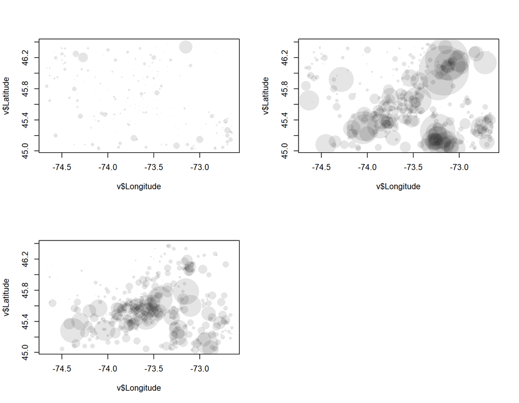

```r
v <- aggregate(. ~ cell + Longitude + Latitude, data = o[, c("cell", "Longitude",
    "Latitude", "PACO", "CAEP", "MODO")], FUN = mean)

par(mfrow = c(2, 2))
plot(v$Longitude, v$Latitude, cex = sqrt(v$PACO), pch = 16, col = gray(level = 0,
    alpha = 0.1))
plot(v$Longitude, v$Latitude, cex = sqrt(v$CAEP), pch = 16, col = gray(level = 0,
    alpha = 0.1))
plot(v$Longitude, v$Latitude, cex = sqrt(v$MODO), pch = 16, col = gray(level = 0,
    alpha = 0.1))
```

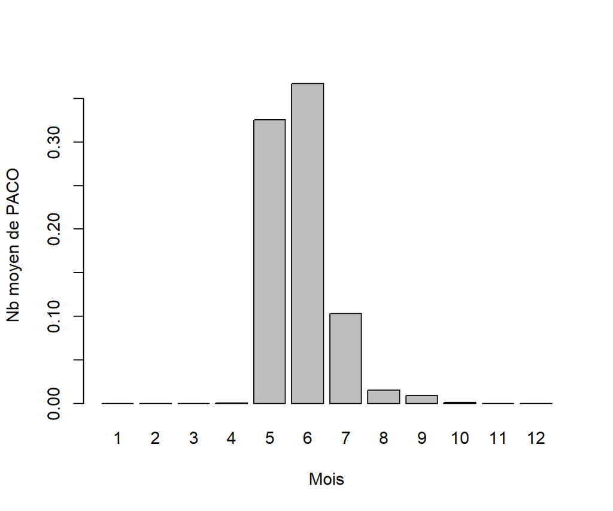

```r
v <- aggregate(PACO ~ month, data = o, mean)

par(mfrow = c(1, 1))
barplot(v$PACO, names.arg = v$month, ylab = "Nb moyen de PACO", xlab = "Mois")
```

Dans mon cas, les “%” ont été transformés en “X.”. Il faut donc utiliser ces mêmes noms. Le code suivant peut se traduire comme voulant dire “trouve la position de ce nom et change le nom en cette position par cet autre nom”.

```r
names(h)[which(names(h) == "X.MilieuNaturel")] <- "naturel"
names(h)[which(names(h) == "X.Agricole")] <- "agricole"
names(h)[which(names(h) == "X.BatiResidentiel")] <- "residentiel"
names(h)[which(names(h) == "X.BatiCommercial")] <- "commercial"
```

Une autre façon de faire pourrait être de remplacer tous les “X.” par qqch d’autres (dans notre cas, par rien)

```r
names(h) <- gsub("X.", "", names(h))
```

Par la suite, on utilise `merge` pour ajouter les données d’habitats aux données d’abondances.

```r
o <- merge(o, h)
head(o)
```

```
##   cell Latitude Longitude PACO CAEP MODO day month year       date naturel
## 1    1   45.033   -72.667    0    0    0  16    12 2006 2006-12-16   86.69
## 2    1   45.033   -72.667    0    0    0  17    12 2005 2005-12-17   86.69
## 3    1   45.033   -72.667    0    0    0  12     8 2006 2006-08-12   86.69
## 4    1   45.033   -72.667    0    0    0  29     5 2007 2007-05-29   86.69
## 5    2   45.033   -72.800    0    0    0  16     1 2005 2005-01-16   92.49
## 6    3   45.033   -72.833    0    0    0  31     8 2008 2008-08-31   93.90
##   agricole residentiel commercial
## 1    10.04        2.64       0.63
## 2    10.04        2.64       0.63
## 3    10.04        2.64       0.63
## 4    10.04        2.64       0.63
## 5     6.96        0.54       0.00
## 6     6.10        0.00       0.00
```

```r
o$urbain <- o$residentiel + o$commercial
```

Encore une fois, ici on pourrait éviter de tracer beaucoup de points en ne prenant que les valeurs uniques pour chaque cellule. Pour ce faire, on pourrait aussi fusionner les données d’habitats avec l’objets `cells` crée plus haut.

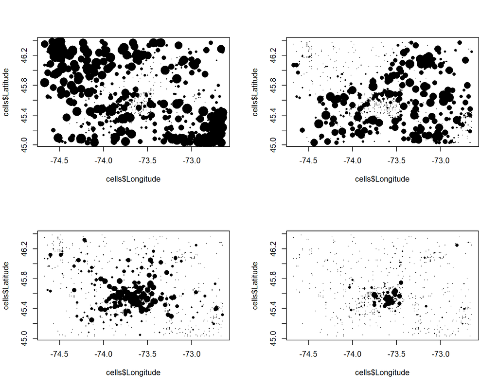

```r
cells <- merge(cells, h)

par(mfrow = c(2, 2))
plot(cells$Longitude, cells$Latitude, cex = 3 * cells$naturel/100, pch = 16)
plot(cells$Longitude, cells$Latitude, cex = 3 * cells$agricole/100, pch = 16)
plot(cells$Longitude, cells$Latitude, cex = 2 * cells$residentiel/100, pch = 16)
plot(cells$Longitude, cells$Latitude, cex = 2 * cells$commercial/100, pch = 16)
```

Si vous voulez visualiser où se trouvent ces cellules, vous pouvez le faire en faisant appel à deux packages, soit **sp** et **mapview**. Voici comment faire.

```r
library(sp)
library(mapview)

coordinates(cells) <- ~Longitude + Latitude  # on indique quelles sont les coordonnées
proj4string(cells) <- "+init=epsg:4326"  # on spécifie le type de projection utilisé (WGS84 en lat/lon)

mapview(cells)  # on trace les points avec différents fond de carte et on ouvre dans le navigateur
```

[interactive chart not shown]

# Atelier 5

Pour cet atelier, nous nous intéresserons aux variables affectant la présence d’une espèce de grenouilles ([Southern Corroboree frog](https://en.wikipedia.org/wiki/Corroboree_frog)) retrouvée en Australie. Pour ce faire, nous avons une base de données frogs.csv avec différentes variables explicatives. Pour cet exercice, vous devrez déterminer quelles sont les variables pertinentes à utiliser pour comprendre ou prédire l’occurrence de l’espèce et vous devrez illustrer les prédictions de votre modèle à l’aide de la fonction `predict` et de graphiques ou encore en utilisant les packages [**visreg**](http://pbreheny.github.io/visreg/) ou [**ggeffects**](https://strengejacke.github.io/ggeffects/articles/introduction_plotmethod.html). Pour mieux comprendre l’utilisation de ces packages, le plus simple est de se référer à leur page web. N’oubliez pas de faire un peu d’explorations de données et de vous poser quelques questions avant de sélectionner vos variables explicatives.

- **pres.abs**: 0 = espèce absente, 1 = espèce présente
- **northing**: coordoonées nord
- **easting**: coordonnées est
- **altitude**: altitude en mètres
- **distance**: distance à la population ou à la mention de présence connue la plus près
- **NoOfPools**: nombre de mares de reproduction potentielles dans le secteur immédiat (dans un certain rayon)
- **avrain**: quantité de pluie moyenne pendant le printemps
- **meanmin**: température moyenne minimale pendant le printemps
- **meanmax**: température moyenne maximale pendant le printemps
1. Étudiez la distribution de vos variables avec la fonction `hist` et les relations entre vos variables avec la fonction `plot` ou autres.
2. Illustrez les présences/absences dans l’espace avec les coordonnées *easting* et *northing*.
3. Construisez et interprétez votre modèle permettant d’expliquer la présence de l’espèce.
4. Utilisez la fonction `predict` ou les packages [**visreg**](https://pbreheny.github.io/visreg/) ou [**ggeffects**](https://strengejacke.github.io/ggeffects/articles/introduction_plotmethod.html) pour illustrer les prédictions de votre modèle. Ces deux packages devraient vous faciliter la tâche comparativement à l’utilisation de `predict`.

## Solution

La première étape consiste à explorer les différentes valeurs de nos variables. On peut faire cela avec la fonction `summary`.

```r
d <- read.csv("https://raw.githubusercontent.com/frousseu/ECL749/master/data/frogs.csv",
    sep = ";")
summary(d)
```

```
##     pres.abs         northing        easting          altitude
##  Min.   :0.0000   Min.   : 84.0   Min.   : 673.0   Min.   :1280
##  1st Qu.:0.0000   1st Qu.:192.0   1st Qu.: 977.8   1st Qu.:1480
##  Median :0.0000   Median :222.5   Median :1023.0   Median :1580
##  Mean   :0.3726   Mean   :228.2   Mean   :1004.6   Mean   :1547
##  3rd Qu.:1.0000   3rd Qu.:290.0   3rd Qu.:1086.2   3rd Qu.:1625
##  Max.   :1.0000   Max.   :335.0   Max.   :1222.0   Max.   :1800
##     distance       NoOfPools          avrain         meanmin
##  Min.   :  250   Min.   :  1.00   Min.   :124.7   Min.   :2.033
##  1st Qu.:  500   1st Qu.:  8.00   1st Qu.:141.7   1st Qu.:2.567
##  Median : 1000   Median : 18.00   Median :148.8   Median :3.000
##  Mean   : 1933   Mean   : 25.11   Mean   :148.1   Mean   :3.120
##  3rd Qu.: 2000   3rd Qu.: 32.00   3rd Qu.:155.0   3rd Qu.:3.567
##  Max.   :18000   Max.   :232.00   Max.   :198.3   Max.   :4.333
##     meanmax
##  Min.   :11.60
##  1st Qu.:12.97
##  Median :13.38
##  Mean   :13.67
##  3rd Qu.:14.21
##  Max.   :15.97
```

Par la suite, il serait préférable d’inspecter les liens entre les différentes variables explicatives potentielles. On peut s’attendre à ce que certaines soient fortement corrélées (*i.e.* **meanmin** et **meanmax**). Pour illustrer toutes les paires de variables, on peut utiliser les fonctions `plot` ou `pairs` appliquées à notre jeu de données. On peut également éliminer la variable réponse et les coordonnées puisque celles-ci ne feront pas partie de nos variables explicatives. Ces trois variables se trouvent dans les 3 premières colonnes de notre tableau et on peut les éliminer en utilisant l’indexage négatif. Les coordonnées pourraient également être utilisées dans notre modèle, mais cela impliquerait que nous pensons qu’il devrait y avoir des gradients (linéaires) de probabilité de présence est-ouest ou nord-sud.

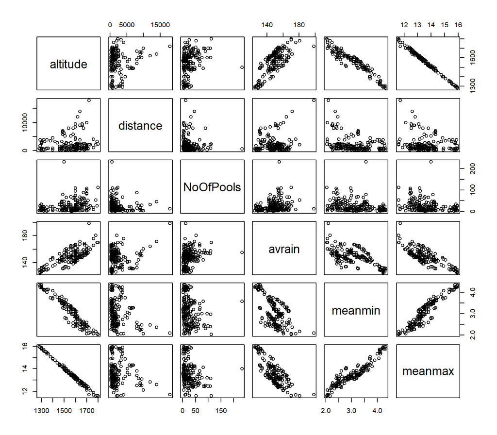

```r
plot(d[, -(1:3)])
```

À première vue, on a une corrélation très forte entre certaines variables, notamment entre l’altitude et les températures minimales et maximales. Il serait donc préférable de choisir l’une ou l’autre de ces variables pour éviter la collinéarité et la redondance dans notre modèle. On pourrait également utiliser la fonction `cor` pour calculer la corrélation entre chacune de nos paires de variables.

```r
cor(d[, -(1:3)])
```

```
##             altitude   distance  NoOfPools     avrain    meanmin    meanmax
## altitude   1.0000000  0.1820645  0.2667913  0.7780271 -0.9536610 -0.9965570
## distance   0.1820645  1.0000000 -0.0959017  0.1484831 -0.3263706 -0.2045681
## NoOfPools  0.2667913 -0.0959017  1.0000000  0.2437792 -0.2237348 -0.2633172
## avrain     0.7780271  0.1484831  0.2437792  1.0000000 -0.6492240 -0.8186997
## meanmin   -0.9536610 -0.3263706 -0.2237348 -0.6492240  1.0000000  0.9462741
## meanmax   -0.9965570 -0.2045681 -0.2633172 -0.8186997  0.9462741  1.0000000
```

On a également une corrélation importante entre la pluie et l’altitude et la température maximale. Encore une fois, il pourrait être important de choisir l’une ou l’autre de ces variables. Bien que la température est certainement très importante pour les amphibiens, l’altitude est selon moi plus utile comme variable si l’intention est de faire de la prédiction sur la présence de l’espèce. En effet, cette variable est probablement plus facilement accessible à l’échelle du paysage comparativement à la température.

Maintenant, on peut également se poser la question quelle est la relation entre les variables explicatives et la probabilité de présence? Pour ce faire, on peut encore une fois utiliser la fonction plot avec une formule. L’utilisation du point `.` indique que nous voulons considérer toutes les variables du tableau de données.

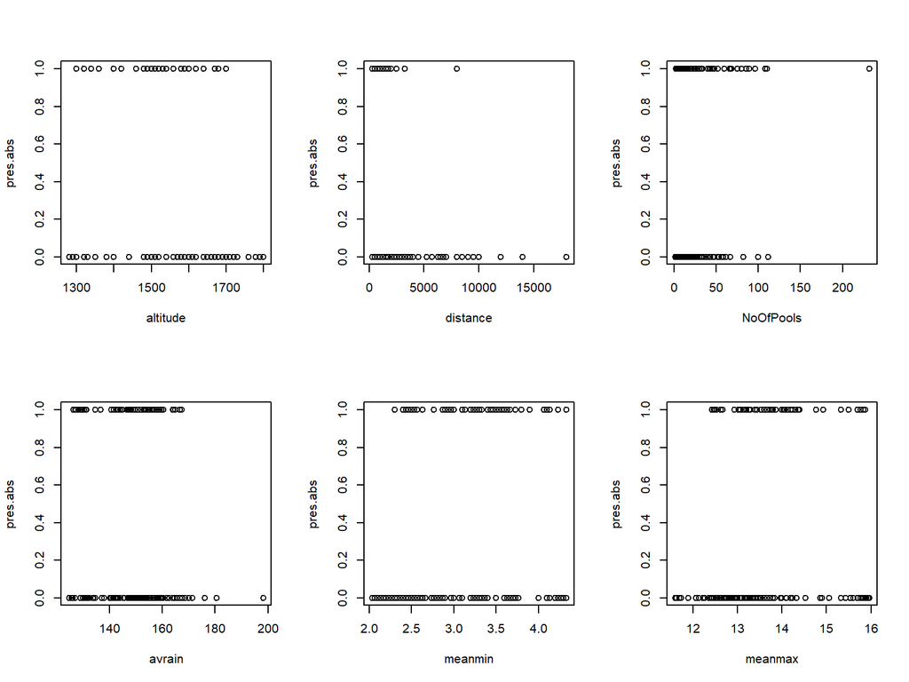

```r
par(mfrow = c(2, 3))
plot(pres.abs ~ ., data = d[, -(2:3)])
```

Ce n’est pas si évident sur les graphiques en raison des valeurs binaires, mais il semble parfois y avoir des probabilité de présence plus élevées pour des valeurs intermédiaires de nos différentes variables environnementales. Si on y réfléchit un peu, ceci n’est pas nécessairement surprenant. Imaginons une espèce fictive ayant une aire de distribution donnée et une variable climatique comme la température moyenne annuelle. Il y aura probablement une température minimale en dessous de laquelle l’espèce ne sera jamais présente ainsi qu’une température maximale au delà de laquelle l’espèce ne sera jamais rencontrée. Si on fait des inventaires à grande échelle pour trouver cette espèce, on obtiendra probablement que l’espèce est davantage rencontrée pour des valeurs intermédiaires de température moyenne annuelle. Il est possible qu’on trouve une relation linéaire positive ou négative entre la température et la présence de l’espèce, mais si on couvre un gradient de température assez étendu, on obtiendra nécessairement que l’espèce est moins abondante ou absente pour les valeurs extrêmes de température de la superficie inventoriée. Dans notre cas, il se pourrait que notre espèce de grenouille se retrouve davantage à des altitudes intermédiaires ce qui pourrait donner lieu à une relation quadratique. Il pourrait donc être judicieux d’inclure des relations quadratiques dans notre modèle.

A *priori*, il ne me semble pas y avoir d’interactions évidentes à inclure dans le modèle. Puisque les variables climatiques sont très fortement corrélées, je ne sélectionnerais que l’altitude. Les deux autres variables me semblent toutes deux pertinentes à inclure. On s’attend à ce que le nombre de mares *NoOfPools* influence positivement la probabilité de présence. Pour ce qui est de la distance, on s’attend à la même relation. En effet, il est raisonnable de penser que plus on est près d’une présence connue, plus on risque de rencontrer l’espèce. L’effet de cette variable est plus à considérer comme étant un indicateur des conditions locales que comme une variable influençant directement la présence de l’espèce. Par exemple, on a de l’information partielle sur la présence de l’espèce dans une région donnée où on veut raffiner nos connaissances de distribution de l’espèce. Elle pourrait également être liée au potentiel de dispersion de l’espèce dans un context de méta-population. Un modèle potentiel serait celui-ci:

```r
m <- glm(pres.abs ~ NoOfPools + distance + altitude + I(altitude^2), family = "binomial",
    data = d)
summary(m)
```

```
##
## Call:
## glm(formula = pres.abs ~ NoOfPools + distance + altitude + I(altitude^2),
##     family = "binomial", data = d)
##
## Deviance Residuals:
##     Min       1Q   Median       3Q      Max
## -1.9904  -0.8161  -0.3054   0.8766   2.8563
##
## Coefficients:
##                 Estimate Std. Error z value Pr(>|z|)
## (Intercept)   -9.446e+01  2.793e+01  -3.382 0.000719 ***
## NoOfPools      3.180e-02  9.482e-03   3.353 0.000799 ***
## distance      -6.221e-04  1.642e-04  -3.789 0.000151 ***
## altitude       1.332e-01  3.806e-02   3.500 0.000466 ***
## I(altitude^2) -4.657e-05  1.291e-05  -3.607 0.000309 ***
## ---
## Signif. codes:  0 '***' 0.001 '**' 0.01 '*' 0.05 '.' 0.1 ' ' 1
##
## (Dispersion parameter for binomial family taken to be 1)
##
##     Null deviance: 279.99  on 211  degrees of freedom
## Residual deviance: 209.25  on 207  degrees of freedom
## AIC: 219.25
##
## Number of Fisher Scoring iterations: 6
```

On peut voir que l’abondance de mares influence positivement la présence de l’espèce, alors que la distance à une présence connue a un effet négatif sur la probabilité de présence de l’espèce. Du côté de l’altitude, il est très difficile de décrire quel est l’effet sur la probabilité de présence sans utiliser de graphiques. On peut toutefois dire que l’effet quadratique semble justifié comme en témoigne la valeur du coefficient du terme quadratique qui est significativement différent de 0. Remarquez l’utilisation de la fonction `I` qui facilite la formulation du modèle et qui permet d’indiquer de la variable altitude est à la base des deux termes (linéaires et quadratiques). Cela peut nous éviter d’avoir à calculer plus de valeurs lorsque nous utiliserons la fonction `predict`.

Visualisons cet effet avec la fonction `predict`. En premier, on crée un `data.frame` avec des valeurs que nous allons soumettre à notre modèle. Pour ce faire, on couvre l’étendue de nos valeurs d’altitude et on fixe les autres variables à leur valeur moyenne.

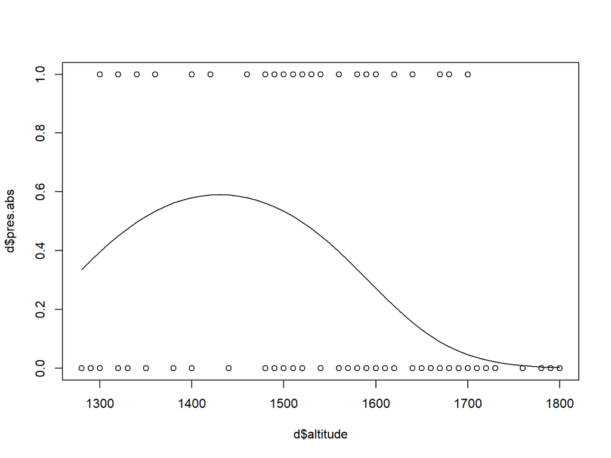

```r
# on fait varier l'altitude de la valeur min à la valeur max par bond de 10
alt <- seq(min(d$altitude), max(d$altitude), by = 10)

# on crée un newdata avec les autres variables fixées à leur valeur moyenne
dat <- data.frame(altitude = alt, NoOfPools = mean(d$NoOfPools), distance = mean(d$distance))

# on sort les prédictions du modèle en précisant que nous les voulons sous
# l'échelle de notre réponse
p <- predict(m, newdata = dat, type = "response")

# on illustre les résultats
plot(d$altitude, d$pres.abs)
lines(alt, p)
```

La probabilité de présence semble atteindre un pic aux alentours de 1400m. Il faut toutefois rester prudent dans l’interprétation précise de ces valeurs, car nous n’avons pas d’intervalles de confiance autour de ces courbes. On pourrait les ajouter en utilisant l’argument `se.fit` de `predict`, mais cela demanderait un peu plus de travail. Nous n’avons d’ailleurs pas encore visualisé l’effet de nos autres variables. Il faudrait produire ces graphiques pour chacune des variables. Il serait possible d’optimiser cette tâche en généralisant le code de prédictions, mais pour l’instant ceci donnerait un code un peu plus difficile à suivre.

Pour faciliter la visualisation des résultats, nous pouvons faire appel au package *visreg* qui s’occupe de la majeure partie du travail. Les deux premières pages vous indiquent de façon assez simple comment créer des graphiques de visualisation d’un modèle linéaire et même comment visualiser une interaction! Le package a même un [site web](http://pbreheny.github.io/visreg/index.html) pour décrire les fonctionnalités. Il y a notamment une section sur les [GLM](http://pbreheny.github.io/visreg/glm.html). Pour ce package, l’argument qui permet de spécifier que l’on veut notre prédiction sous l’échelle de la réponse s’appelle `scale` contrairement à `type` pour la fonction `predict`.

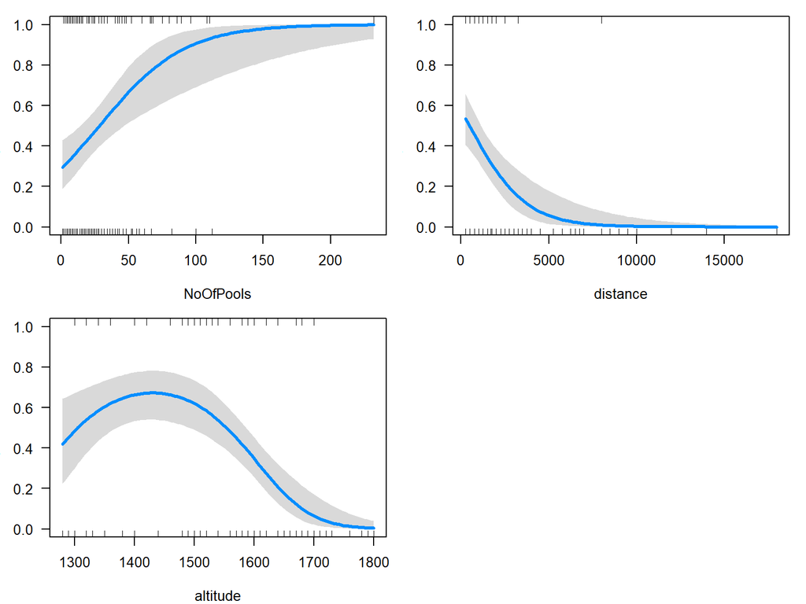

```r
library(visreg)

par(mfrow = c(2, 2), mar = c(4, 3, 1, 1))
visreg(m, scale = "response", ylim = 0:1)
```

Certains ont utilisé les coordonnées comme variables explicatives dans leur modèle. Ceci n’est pas nécessairement mauvais, mais cela mérite une bonne réflexion. Est-ce que la relation entre la présence et les coordonnées est linéaire ou est-elle plus complexe? Est-ce que la relation entre les coordonnées et la probabilité de présence pourrait servir à prédire la présence de l’espèce dans d’autres régions? Probablement pas. Si le but est de prédire la présence de l’espèce seulement à l’intérieur de la zone étudiée, les coordonnées pourraient être utilisées. Cependant, il faudrait s’assurer que la relation est linéaire, ce qui serait assez suprenant. Si c’est le cas, il faudrait plutôt se demander s’il n’y a pas une ou des variables non prises en compte qui pourraient créer un tel gradient de probabilité de présence dans l’aire d’étude. Si on s’intéresse à comprendre l’influence des variables environnementales sur l’occurence des grenouilles à l’extérieur de la zone étudiée, la relation observée avec les coordonnées devient probablement inutile.

Malheureusement, ou plutôt heureusement, il n’y a pas nécessairement une meilleure ou une unique réponse à ce défi d’analyse de données. La mienne n’est qu’une suggestion et vous avez peut être de meilleures suggestions. L’important est de justifier nos choix et de prendre en considération les éléments les plus importants. Un élément important que j’ai ignoré est la potentielle corrélation spatiale entre les observations. Par exemple, est-ce que les observations près les unes des autres peuvent être considérées comme étant indépendantes? Aussi, est-ce qu’il y aurait d’autres variables à prendre en compte dans cette analyse? Comment les inventaires ont été réalisés? Est-ce qu’il faudrait tenir compte de la probabilité de détection de l’espèce?

# Atelier 6

## Les parasites chez le Colibri à gorge rubis

Pour cet exercice, vous étudierez ce qui influence la charge parasitaire chez le Colibri à gorge rubis (*Archilochus colubris*), une espèce retrouvée au Québec. Dans la base de données colibris.csv, vous retrouverez différentes variables comme le sexe (4 = mâle, 5 = femelle) et l’âge (1 = adulte, 2 = jeune). L’exercice consiste à déterminer quelles sont les variables qui affectent la quantité de parasites. Vérifiez également les conditions d’application de votre modèle avec le package [DHARMa](https://cran.r-project.org/web/packages/DHARMa/vignettes/DHARMa.html). Pour interpréter vos résultats, illustrez graphiquement votre modèle. Obtenez-vous des conclusions semblables si vous faites l’analyse en présence/absence? Pour transformer les valeurs en présence/absence, vous pouvez utiliser la fonction `ifelse`.

### Solution

On importe d’abord les données et on affiche notre `data.frame` et un petit résumé de ce qu’il contient.

```r
d <- read.csv("https://raw.githubusercontent.com/frousseu/ECL749/master/data/colibris.csv")
head(d)
```

```
##    bague sexe age masse parasites
## 1 E09801    4   1   3.2         0
## 2 E09802    4   2   3.0         0
## 3 E09808    4   1   3.5         3
## 4 E09809    4   1   3.6         0
## 5 E09810    4   1   3.6         0
## 6 E09812    5   1   3.9         0
```

```r
summary(d)
```

```
##     bague                sexe            age            masse
##  Length:373         Min.   :4.000   Min.   :1.000   Min.   :2.500
##  Class :character   1st Qu.:4.000   1st Qu.:1.000   1st Qu.:2.900
##  Mode  :character   Median :4.000   Median :1.000   Median :3.200
##                     Mean   :4.466   Mean   :1.204   Mean   :3.273
##                     3rd Qu.:5.000   3rd Qu.:1.000   3rd Qu.:3.600
##                     Max.   :5.000   Max.   :2.000   Max.   :5.200
##                                                     NA's   :1
##    parasites
##  Min.   : 0.000
##  1st Qu.: 0.000
##  Median : 1.000
##  Mean   : 4.491
##  3rd Qu.: 7.000
##  Max.   :40.000
##  NA's   :4
```

On voit quelques zéros dans la colonne *parasites* et on peut donc se demander à quel type de données nous avons à faire. On peut illustrer les valeurs de *parasites* avec un histogramme.

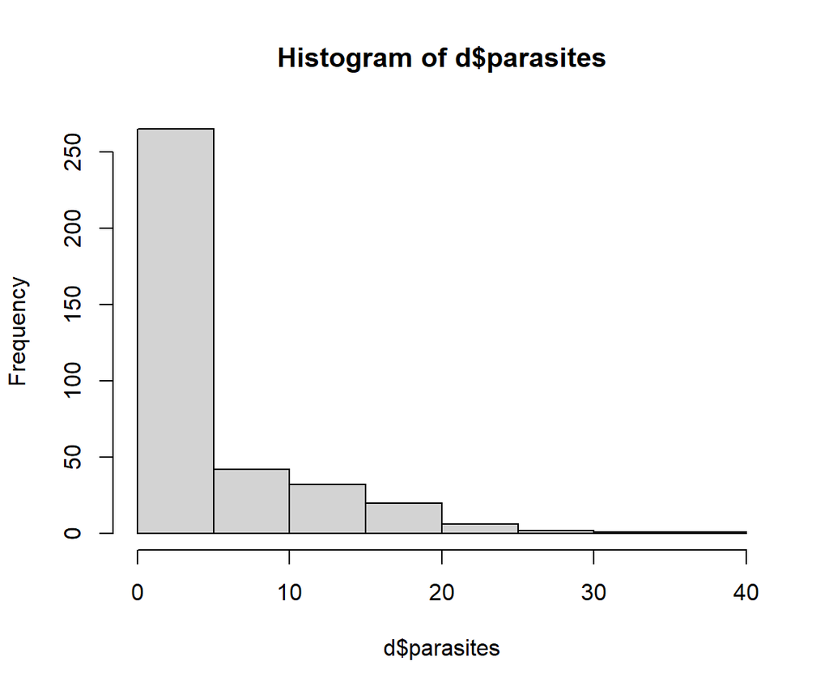

```r
hist(d$parasites)
```

On a ici un nombre d’individus, avec des valeurs allant de 0 à environ 40. Il faudra donc probablement modéliser l’abondance de parasites avec une distribution de Poisson. On a également plusieurs colibris dans la base de données. Une deuxième question à se poser est est-ce qu’on a plusieurs comptes de parasites pour un même individus? On peut vérifier ceci en utilisant la fonction `table` qui va comptabiliser le nombre de fois que chaque numéro de bague apparaît dans la base de données. En utilisant une seconde fois la fonction `table`, on compte le nombre de fois où chacune de ces valeurs est observée.

```r
table(table(d$bague))
```

```
##
##   1   2   3   4
## 243  48  10   1
```

On voit que pour la majorité des individus, on a une seule valeur, mais certains ont plusieurs valeurs (2, 3 ou 4 observations). On devrait donc par défaut se diriger vers les modèles mixtes pour traiter l’individu comme un effet aléatoire puisque les comptes de parasites sur un même individu ne sont pas indépendants. Par contre, puisque la majorité des individus ont une seule observation, cela peut créer des problèmes dans le cadre des modèles mixtes et on pourrait plutôt opter pour effectuer une moyenne ou pour une sélection aléatoire d’une seule observation pour les individus ayant plusieurs observations. On pourrait également comparer les deux approches et déterminer si nos conclusions par rapport à l’effet de nos variables sont fortement affectées par notre méthode d’analyse. Si ce n’est pas le cas, on peut choisir la méthode qui nous convient en justifiant notre choix et en exposant le fait que nos conclusions ne sont pas affectées par la méthode choisie.

On devrait également explorer les liens entre nos variables explicatives. On peut faire ceci avec des `boxplot` ou des graphiques standards.

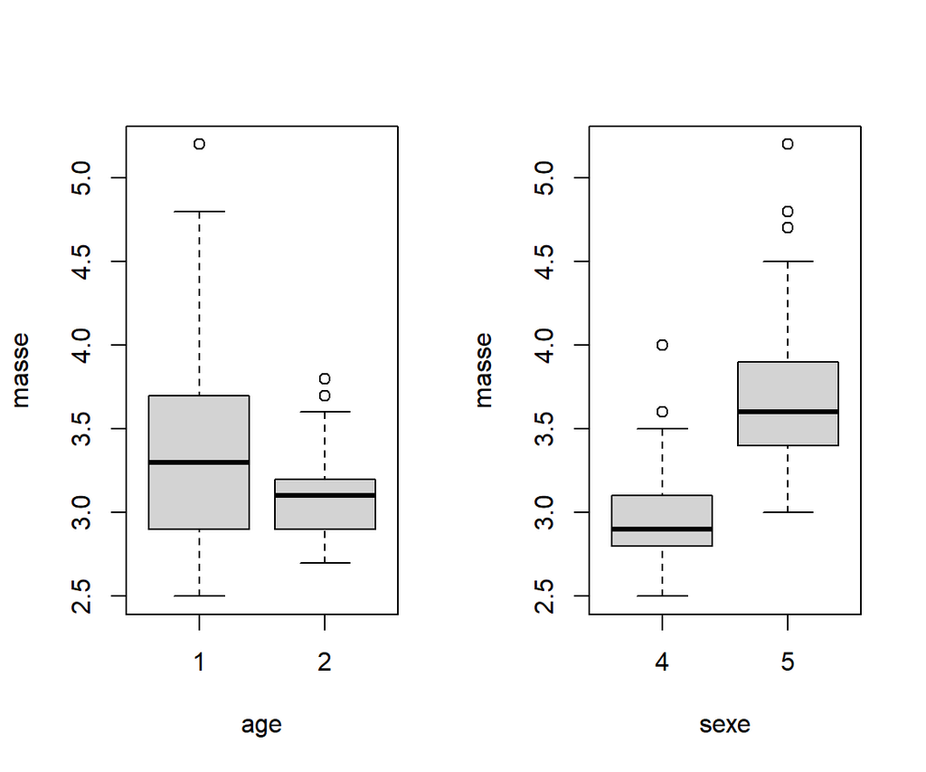

```r
par(mfrow = c(1, 2))
boxplot(masse ~ age, data = d)
boxplot(masse ~ sexe, data = d)
```

```r
table(d$sexe, d$age)
```

```
##
##       1   2
##   4 136  63
##   5 161  13
```

Les femelles sont plus massives que les mâles et les adultes semblent également plus massifs que les jeunes. Cependant, il semble y avoir une disproportion de mâles par rapport aux femelles chez les jeunes.

Avant de lancer nos modèles, il faut transformer le sexe et l’âge en facteur étant donné que ces deux variables sont représentées par des valeurs numériques.

```r
d$sexe <- as.factor(d$sexe)
d$age <- as.factor(d$age)

library(lme4)
m <- glmer(parasites ~ sexe + age + masse + (1 | bague), data = d, family = poisson)

summary(m)
```

```
## Generalized linear mixed model fit by maximum likelihood (Laplace
##   Approximation) [glmerMod]
##  Family: poisson  ( log )
## Formula: parasites ~ sexe + age + masse + (1 | bague)
##    Data: d
##
##      AIC      BIC   logLik deviance df.resid
##   2065.3   2084.9  -1027.7   2055.3      363
##
## Scaled residuals:
##     Min      1Q  Median      3Q     Max
## -2.8667 -0.6979 -0.1469  0.1926  4.9784
##
## Random effects:
##  Groups Name        Variance Std.Dev.
##  bague  (Intercept) 2.612    1.616
## Number of obs: 368, groups:  bague, 299
##
## Fixed effects:
##             Estimate Std. Error z value Pr(>|z|)
## (Intercept)   3.7788     0.6460   5.850 4.93e-09 ***
## sexe5        -0.1041     0.2626  -0.396    0.692
## age2          0.1008     0.1566   0.644    0.520
## masse        -1.0082     0.2177  -4.632 3.62e-06 ***
## ---
## Signif. codes:  0 '***' 0.001 '**' 0.01 '*' 0.05 '.' 0.1 ' ' 1
##
## Correlation of Fixed Effects:
##       (Intr) sexe5  age2
## sexe5  0.409
## age2   0.115  0.243
## masse -0.970 -0.548 -0.202
```

Un petit élément que nous n’avons pas encore vérifié est si le modèle est approprié pour les données. Par exemple, est-ce qu’il y a de la surdispersion? On peut vérifier cela facilement avec le package [DHARMa](https://cran.r-project.org/web/packages/DHARMa/vignettes/DHARMa.html).

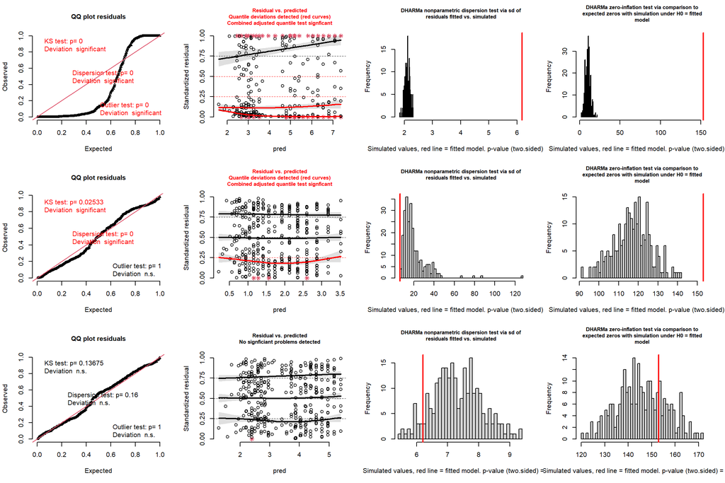

```r
library(DHARMa)
library(glmmTMB)

m1 <- glm(parasites ~ sexe + age + masse, data = d, family = poisson)
m2 <- glmer(parasites ~ sexe + age + masse + (1 | bague), data = d, family = poisson)
m3 <- glmmTMB(parasites ~ sexe + age + masse + (1 | bague), data = d, family = "nbinom1")

par(mfrow = c(3, 4))
testUniformity(m1)
testQuantiles(m1)
testDispersion(m1)
testZeroInflation(m1)
testUniformity(m2)
testQuantiles(m2)
testDispersion(m2)
testZeroInflation(m2)
testUniformity(m3)
testQuantiles(m3)
testDispersion(m3)
testZeroInflation(m3)
```

Le premier modèle ne semble pas du tout approprié. Il semble y avoir une très forte surdispersion ou surabondance de zéros. Les deux modèles suivants avec effets aléatoires semblent beaucoup mieux répondre aux suppositions de bases du modèle. Il est fort probable que l’effet aléatoire sur les individus capture une bonne partie de la surdispersion. Dans le modèle 2 avec une distribution de Poisson, il y a encore un peu de surdispersion/surabondance de zéros comparativement au modèle 3. Pour ce dernier modèle, l’utilisation d’une distribution négative-binomiale (distributiuon qui permet plus de flexibilité quant à la variance comparativement à une distirbution de Poisson) permet d’obtenir un modèle qui semble approprié pour les données.

```r
library(ggeffects)
```

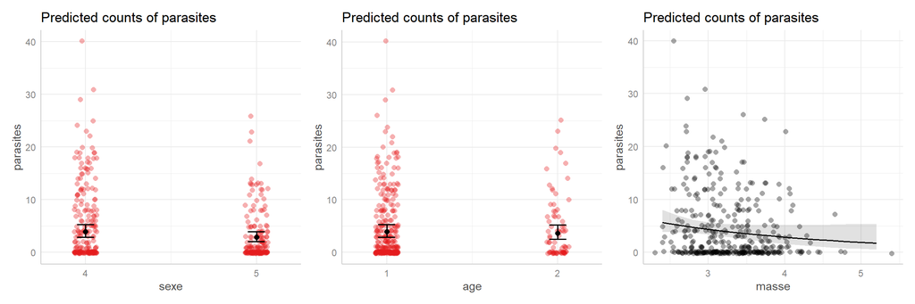

```r
library(patchwork)
p1 <- plot(ggpredict(m3, terms = "sexe"), add.data = TRUE)
p2 <- plot(ggpredict(m3, terms = "age"), add.data = TRUE)
p3 <- plot(ggpredict(m3, terms = "masse"), add.data = TRUE)
wrap_plots(list(p1, p2, p3))
```

```r
summary(m3)
```

```
##  Family: nbinom1  ( log )
## Formula:          parasites ~ sexe + age + masse + (1 | bague)
## Data: d
##
##      AIC      BIC   logLik deviance df.resid
##   1776.6   1800.1   -882.3   1764.6      362
##
## Random effects:
##
## Conditional model:
##  Groups Name        Variance Std.Dev.
##  bague  (Intercept) 0.5153   0.7179
## Number of obs: 368, groups:  bague, 299
##
## Overdispersion parameter for nbinom1 family (): 7.76
##
## Conditional model:
##             Estimate Std. Error z value Pr(>|z|)
## (Intercept)  2.72643    0.72798   3.745  0.00018 ***
## sexe5       -0.30988    0.22921  -1.352  0.17638
## age2        -0.07781    0.18233  -0.427  0.66954
## masse       -0.41674    0.24572  -1.696  0.08989 .
## ---
## Signif. codes:  0 '***' 0.001 '**' 0.01 '*' 0.05 '.' 0.1 ' ' 1
```

On conclut que bien qu’il y ait des tendances, il n’y a pas d’effets évidents du sexe, de l’âge ou de la masse sur le nombre de parasites.

## La richesse spécifique le long du littoral

Ici, on s’intéresse aux variables influençant le nb d’espèces rencontrées le long du littoral. On a la hauteur de la station d’échantillonnage par rapport à la hauteur moyenne de la marée ainsi que l’exposition qui est quantifiée à l’aide d’un index construit à partir de la “sévérité” des conditions de la station (force des vagues, longueur de la zone d’impact, pente, substrat allant de fin à grossier). La base de données se trouve à cet endroit plages.csv. Une autre base de données plage_type.csv est également disponible où le type de plage (roches ou sable) est donnée. Vous devrez fusionner ces deux bases de données pour mettre l’information dans une même base de données. Pour ce faire, vous devrez utiliser la fonction `merge`. Illustrez les résultats de votre modèle. Vérifiez les conditions d’application de votre modèle avec le package [DHARMa](https://cran.r-project.org/web/packages/DHARMa/vignettes/DHARMa.html).

### Solution

Importons d’abord les données.

```r
d <- read.csv("https://raw.githubusercontent.com/frousseu/ECL749/master/data/plages.csv")
h <- read.csv("https://raw.githubusercontent.com/frousseu/ECL749/master/data/plage_type.csv")
head(d)
```

```
##   sample richesse exposition hauteur plage
## 1      1       11         10   0.045     1
## 2      2       10         10  -1.036     1
## 3      3       13         10  -1.336     1
## 4      4       11         10   0.616     1
## 5      5       10         10  -0.684     1
## 6      6        8          8   1.190     2
```

```r
head(h)
```

```
##   Plage   Type
## 1     1 roches
## 2     2  sable
## 3     3 roches
## 4     4  sable
## 5     5  sable
## 6     6 roches
```

Nous pouvons utiliser la fonction `merge` pour fusionner les données d’habitat ou de types de plages aux données d’observation de richesse. Mais attention, les colonnes avec les identifiants de plages diffèrent entre les deux jeux de données (*plage* et *Plage*). Il faut donc spécifier à `merge` quelles colonnes utiliser pour la fusion entre les deux jeux de données. Si on ne le fait pas, le résultat de `merge` contiendra les deux colonnes et les associations ne se feront pas correctement.

```r
d <- merge(d, h, by.x = "plage", by.y = "Plage")
```

Comme pour l’exercice précédent, on a une variable réponse qui correspond à un compte et qui est très asymmétrique à droite avec des valeurs de zéros.

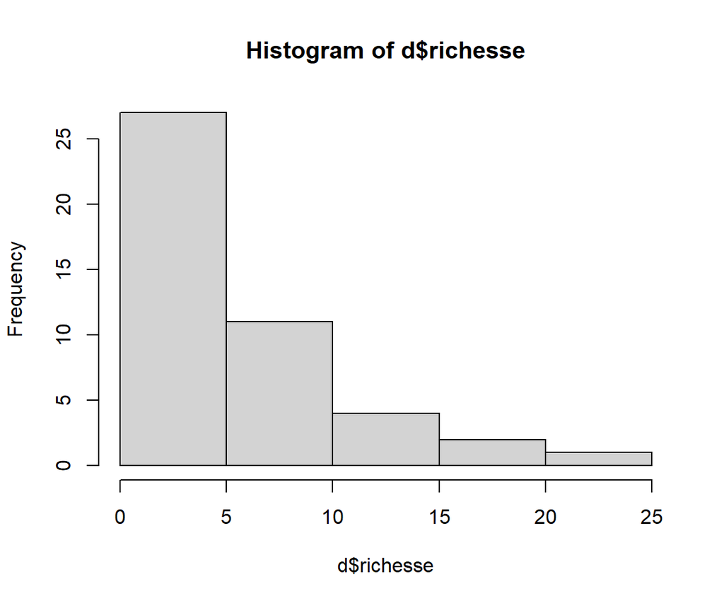

```r
hist(d$richesse)
```

```r
range(d$richesse)
```

```
## [1]  0 22
```

On semble également avoir des comptes effectués sur plusieurs plages. Vérifions ceci avec la fonction `table`.

```r
table(d$plage)
```

```
##
## 1 2 3 4 5 6 7 8 9
## 5 5 5 5 5 5 5 5 5
```

On a cinq observations par plages et 9 plages. Idéalement, il faudrait utiliser des modèles mixtes avec la plage en effet aléatoire. On devrait également explorer les liens entre les différentes variables. On peut inclure à la fois la richesse et les variables explicatives ce qui nous permettra d’un seul coup de vérifier le lien apparent avec les variables explicatives et la corrélation entre les variables explicatives.

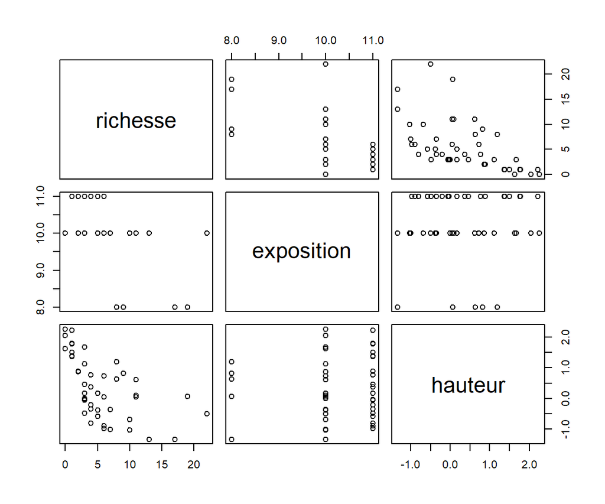

```r
plot(d[, c("richesse", "exposition", "hauteur")])
```

On remarque premièrement qu’il n’y a que trois valeurs d’exposition. On pourrait décider de traiter cette variable comme un facteur, mais puisque l’effet semble linéaire et qu’on peut s’imaginer que les valeurs représentent un gradient on pourrait également décider de les traiter comme une variable numérique.

```r
library(lme4)
m <- glmer(richesse ~ hauteur + exposition + Type + (1 | plage), data = d, family = poisson)
summary(m)
```

```
## Generalized linear mixed model fit by maximum likelihood (Laplace
##   Approximation) [glmerMod]
##  Family: poisson  ( log )
## Formula: richesse ~ hauteur + exposition + Type + (1 | plage)
##    Data: d
##
##      AIC      BIC   logLik deviance df.resid
##    212.1    221.1   -101.0    202.1       40
##
## Scaled residuals:
##     Min      1Q  Median      3Q     Max
## -1.7844 -0.5354 -0.2592  0.1692  4.3418
##
## Random effects:
##  Groups Name        Variance Std.Dev.
##  plage  (Intercept) 0.0275   0.1658
## Number of obs: 45, groups:  plage, 9
##
## Fixed effects:
##             Estimate Std. Error z value Pr(>|z|)
## (Intercept)  6.74022    1.02599   6.570 5.05e-11 ***
## hauteur     -0.48707    0.07467  -6.523 6.88e-11 ***
## exposition  -0.48355    0.09607  -5.033 4.82e-07 ***
## Typesable   -0.20082    0.20666  -0.972    0.331
## ---
## Signif. codes:  0 '***' 0.001 '**' 0.01 '*' 0.05 '.' 0.1 ' ' 1
##
## Correlation of Fixed Effects:
##            (Intr) hauter expstn
## hauteur     0.186
## exposition -0.989 -0.154
## Typesable  -0.525 -0.278  0.420
## convergence code: 0
## Model failed to converge with max|grad| = 0.00208465 (tol = 0.002, component 1)
```

On a des effets négatifs significatifs des deux variables ce qui signifie que la hauteur et l’exposition sont toutes deux associées à un moins grand nombre d’espèces. On peut visualiser l’effet de ces deux variables avec `visreg`.

```r
library(visreg)
par(mfrow = c(2, 3))
visreg(m, scale = "linear")
```

[output not shown]

```r
visreg(m, scale = "response")
```

[output not shown]

En utilisant le package **ggeffects** plutôt que visreg, on peut obtenir des intervalles de confiance approximatifs qui nous aident un peu plus à se faire une idée de l’incertitude que nous avons dans l’estimation de nos effets. Ce package permet également un peu plus de flexibilité dans la visualisation des modèles comparativement à visreg. En combinaison avec le package [**patchwork**](https://patchwork.data-imaginist.com/index.html), il est facile d’organiser les différents graphiques dans une même fenêtre.

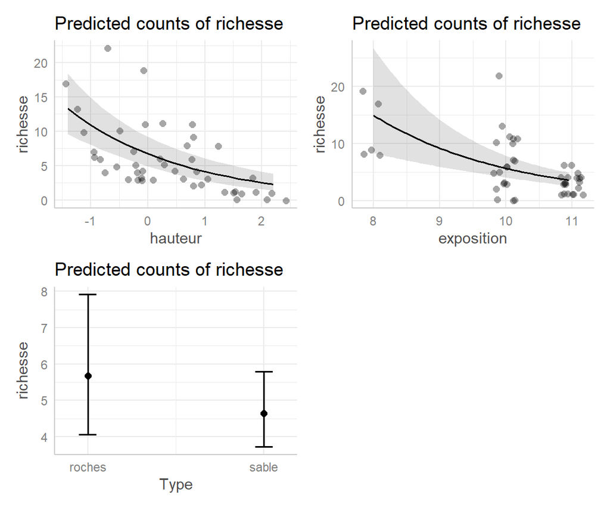

```r
library(ggeffects)

g1 <- ggpredict(m, terms = c("hauteur"))
g1 <- plot(g1, add.data = TRUE)
g2 <- ggpredict(m, terms = c("exposition[n=50]"))
g2 <- plot(g2, add.data = TRUE)
g3 <- ggpredict(m, terms = c("Type"))
g3 <- plot(g3, add.data = FALSE)

library(patchwork)

g1 + g2 + g3 + plot_layout(ncol = 2)
```

# Atelier 7

Pour cet atelier, vous vous pratiquerez à présenter des méthodes et des résultats. Vous devrez effectuer l’analyse de deux bases de données, présenter les méthodes utilisées et présenter les résultats de vos analyses. Puisque vous n’avez pas énormément d’informations sur la façon dont les données ont été récoltées, vous vous concentrerez surtout sur les méthodes statistiques qui ont été utilisées pour effectuer vos analyses.

## Effet de lumières dissuasives sur les taux de visites par les prédateurs du mouton, Argentine.

Dans ce projet, un des objectifs était de déterminer l’efficacité de lumières dissuasives pour réduire la prédation du bétail par les prédateurs (renards, cougars). Pour ce faire, des caméras-trappes ont été installées dans un certain nombre de champs afin d’enregistrer la présence de prédateurs. Le nombre de visites de prédateurs enregistré en présence ou en absence de lumières dissuasives par chaque caméra a été compilé afin de déterminer si les lumières ont un effet négatif sur le nombre de visites par les prédateurs. Dans la base de données [lumiere_predateur](https://raw.githubusercontent.com/frousseu/ECL749/master/data/lumiere_predateur.csv), vous avez la présence (1) ou l’absence (0) de lumières, l’identifiant du **champ**, l’identifiant de la **camera**, le nombre de visites par des prédateurs (**nbpred**) et le nombre de jours avec ou sans lumière (**nbjour**). Ces données ont été récoltés à l’été 2019 par un étudiant en stage. Puisque le nombre de jours d’installation change d’une caméra à l’autre, il faudra ajuster le modèle pour tenir compte de ce changement qui peut avoir une influence sur le nb de prédateurs détectés. Pour cela, vous devrez utiliser un *offset* qui permet en quelque sorte de standardiser les observations pour le nombre de jours d’enregistrement. Dans la formule de votre modèle, vous pouvez ajouter un *offset* de cette façon:

```r
glm(y ~ x1 + x2 + offset(log(nbjour)), data = d)
```

### Solution

Importons d’abord les données.

```r
d <- read.csv("https://raw.githubusercontent.com/frousseu/ECL749/master/data/lumiere_predateur.csv")
head(d)
```

```
##   champ camera lumiere nbpred nbjour
## 1     A     A1       0     18     72
## 2     A     A2       0     11     72
## 3     A     A3       0      1     72
## 4     B     B1       0     10     70
## 5     B     B2       0      1     70
## 6     B     B3       0      9     70
```

On doit également faire un peu d’exploration de données avant de procéder à l’analyse.

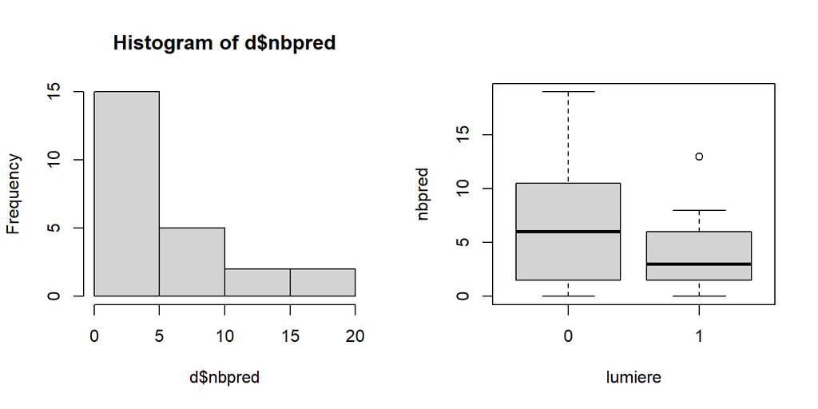

```r
par(mfrow = c(1, 2))
hist(d$nbpred)
boxplot(nbpred ~ lumiere, data = d)
```

Puisque le nombre de prédateur est un nombre d’individus, un glm avec une distribution de Poisson devrait être utilisé. Aussi, nous avons des mesures répétées par champ et par caméra. Il serait donc nécessaire de traiter ces deux variables comme des effets aléatoires dans notre analyse. Ici, je ne vais utiliser que les caméras comme effet aléatoire en raison de problèmes de convergence lorsque le champ est également considéré. Ceci est possiblement dû au fait qu’il y a trop peu de champ pour traiter cette variable comme un effet aléatoire.

Un autre élément important à remarquer est que le nombre de jours pendant lesquels les caméras et les lumières ont été installées semblent changer d’une caméra à l’autre. Il faudra tenir compte de cela si nous comparons le nombre de prédateurs vus d’une caméra et d’un traitement à l’autre. Nous pouvons prendre cela en compte par l’intermédiaire d’un [*offset*](https://stats.stackexchange.com/questions/11182/when-to-use-an-offset-in-a-poisson-regression). Plûtot que de modéliser le nombre de prédateur vus, le *offset* nous permettra de modéliser un taux d’observation de prédateurs. Ici, cela reviendra à modéliser un nombre de prédateurs vu par jour étant donné que nous utilisons le nombre de jour. Une transformation *log* est appliquée sur le nombre de jour puisque la relation est étudiée sur une échelle logarithmique par l’intermédiaire d’une fonction de lien *log*.

```r
library(lme4)

d$lumiere <- as.factor(d$lumiere)
m <- glmer(nbpred ~ lumiere + offset(log(nbjour)) + (1 | camera), data = d, family = poisson())
summary(m)
```

```
## Generalized linear mixed model fit by maximum likelihood (Laplace
##   Approximation) [glmerMod]
##  Family: poisson  ( log )
## Formula: nbpred ~ lumiere + offset(log(nbjour)) + (1 | camera)
##    Data: d
##
##      AIC      BIC   logLik deviance df.resid
##    147.9    151.5    -71.0    141.9       21
##
## Scaled residuals:
##     Min      1Q  Median      3Q     Max
## -2.0149 -0.9365 -0.0734  0.8227  3.4439
##
## Random effects:
##  Groups Name        Variance Std.Dev.
##  camera (Intercept) 0.2867   0.5354
## Number of obs: 24, groups:  camera, 12
##
## Fixed effects:
##             Estimate Std. Error z value Pr(>|z|)
## (Intercept)  -2.2988     0.1949 -11.792   <2e-16 ***
## lumiere1     -0.4474     0.1786  -2.505   0.0122 *
## ---
## Signif. codes:  0 '***' 0.001 '**' 0.01 '*' 0.05 '.' 0.1 ' ' 1
##
## Correlation of Fixed Effects:
##          (Intr)
## lumiere1 -0.328
```

On voit que la présence de lumières dissuasives semble avoir un effet négatif sur le taux de visite par les prédateurs. Toutefois, avant de conclure sur cet effet, il serait important de vérfier les suppositions de bases de notre modèle.